# Global Value Chains: NAFTA

| Name | examnr. |
| --- | --- |
| Adelina Sharipova | 2018931 |
| Jesse Bijnen | 1258985 |

2. Terminology and concepts

```
2.1. Global Value Chains and World Input-Output Tables
```

```
2.2. NAFTA and Standardization
```

3. Input-Output Analysis

```
3.1 Regional Trade Flows in Intermediate Manufacturing Goods
```

```
3.2 North American Global Value Chain
```

4. Relation to Revealed Comparative Advantage

5. Conclusion

# Research question

Can we identify a North-American value chain, and if yes, what role did NAFTA play in the realization of this regional value chain?

## 1 Introduction

More than half of the global exports manufactured imports are intermediate goods (primary goods, parts and components, and semi-finished products), and more than 70 percent of world services imports are intermediate goods [(De Backer and Miroudot, 2013)](https://www.ecb.europa.eu/pub/pdf/scpwps/ecbwp1677.pdf?11ce331dcdb55ca6ba38f8b0c288c4a4) . These products within world production and world trade fall under “global value chains” (GVCs), where the different stages of the production (and trade) process are located across different countries [(OECD)](http://www.oecd.org/sti/ind/global-value-chains.htm). The GVCs are production chains where every step of the production process adds a certain value to the product.

The most important feature of the GVCs is that companies restructure their operations internationally, so that the dispersion of value chain activities is located across different countries. [Baldwin and Lopez-Gonzalez (2014)](http://www.nber.org/papers/w18957) show that the GVCs are not spread globally, as they are spread more regionally. The authors argue that there is a distinctive European, Asian and North-American value chain, that is concentrated respectively around Germany, Japan and the United States (US). This is the motivation behind this research project: we want to analyze the existence of the (regional) North-American value chain and its evolution through time. Furthermore, we investigate whether or not the North American Free Trade Agreement (NAFTA) has played an important role. The research question of this project is: can we identify a North-American value chain, and if yes, what role did NAFTA play in the realization of this regional value chain?

We start in the next section by a short terminology and explanation of some concepts. Next, we present the actual input-output analysis for 1995 and for 2011. Thereby we are interested in what kind of products (from which sectors) are being traded within the GVC context, and how the individual North-American countries relate to one another. Lastly, we look whether or not the found results match with the evolution of the Revealed Comparative Advantage (RCA) index. But first, let us take a quick look at what NAFTA stands for.

```python
from IPython.display import YouTubeVideo

YouTubeVideo('DwKR08t5BGA')
```

[video not shown]

## 2 Terminology and concepts

### 2.1 Global Value Chains and World Input Output Tables

GVCs split the production process into separate phases and spread those across different countries. The rise of the GVCs is characterized by the strong globalisation in the past decades of foreign direct investments, trade and manufacturing [(Felipe, 2012)](http://hdl.handle.net/11540/286). Typical for the GVCs is the vertical supply chain structure, where different vertical steps of the production process are geographically separated from each other.

The GVCs connect consumers in developed countries with low skilled labor force in the developing countries. Mostly, the developed countries outsource the parts of the production process that require relatively more low skilled labor to the developing countries. Consecutively, they focus then on the parts that require relatively more of the high skilled labor. This way, there develops a divergence between the headquarters economies that focus on core businesses and manufacturing economies that focus on partly fabricating the by them imported intermediate inputs. After the outsourcing of those low skilled labor intensive production steps, the developed countries re-import the partly fabricated intermediate inputs, where the value added by the developing countries is not very large. The next step of the production process by the developed countries is the completion of the manufactured goods. The re-imports by the developed countries are the re-exports by the developing countries and are thus the opposite of each other.

To detect the presence and to analyze the characteristics of the North-American value chain we use the world input-output tables by [(WIOD, 2015)](http://onlinelibrary.wiley.com/doi/10.1111/roie.12178/epdf). Such a table gives us the quantities of the inputs in different countries and from which sectors these come from. Rows show us how the output of a sector is divided between the intermediate inputs from other sectors and from the final consumption. The columns represent the quantities of the intermediate inputs from other sectors. Shortly put, input-outputtables prove the state of the interdependence between the production in different countries and different sectors.

### 2.2 NAFTA and Standardization

As the introductory video already mentioned, NAFTA is an agreement between Canada, Mexico and the US, introducing a free trade zone between the countries. The main goal is to facilitate trade by mutually importing and exporting goods. The agreement in 1994 eliminated almost all tariff barriers and a lot of non-tariff barriers. An important component of the NAFTA agreement are the rules on standardization. Specifically that brought harmonisation of productstandards and mutual quality controles. The thought behind this standardization is to bring parallel standards to the markets and to ease this way the trade between the countries.

## 3 Input Outputanalysis

Historically, the three partner countries have known a big increase in trade in general (see the interactive map here below). In the graph we have plotted the data from Gapminder.org: the imports of goods and services (% of GDP) of each country on the x-axis and the exports on the y-axis. We see for the period starting from 1960 an increase in trade in all partnercountries.

For the actual analysis of the GVC in North-America, we are using the data from the World Input-Output Tables from 1995 to 2011 (the latest release from 2013 for the period 1995-2011 with the same classification according to the International Standard Industrial Classification revision 3, ISIC Rev. 3).

Firstly, we will observe the internal trade flows within the three countries (Canada, US and Mexico). This is a descriptive part of the analysis, because we only focus on the trade flows in intermediate manufacturing goods between these countries mutually and versus the world. I.e. we look at how much they trade in manufacturing intermediate products with each other, both for 1995 and 2011.

Secondly, we compute the actual GVC for the three countries by calculating the bilateral re-exports for each country. This is a necessary step to look at the evolution of the trade flows between the three countries and to pin down the regional North-American value chain. After that, we can conclude what role NAFTA played in the regional value chain.

```python
import plotly
plotly.tools.set_credentials_file(username= 'adelina1789', api_key= 'Nx5SiPRVHGivzzFIjcnL')
import plotly.plotly as py
import plotly.graph_objs as go

import pandas as pd
import math

dataExp = pd.read_csv("Exports (p of GDP).csv", delimiter = ',')
dataImp = pd.read_csv("Imports (p of GDP).csv", delimiter = ';')


dataExp = dataExp.sort_values(['Year', 'Country'])
dataImp = dataImp.sort_values(['Year', 'Country'])

trace0 = go.Scatter(
    x=dataImp['Imports of goods and services (% of GDP)'][dataImp['Country'] == 'Canada'],
    y=dataExp['Exports of goods and services (% of GDP)'][dataExp['Country'] == 'Canada'],
    mode='markers',
    name='Canada',
    text=dataExp['Year'][dataExp['Country'] == 'Canada'],
    marker=dict(
        symbol='circle',
        sizemode='area',
        sizeref= 2,
        size=10,
        line=dict(
            width=2
        ),
    )
)

trace1 = go.Scatter(
    x=dataImp['Imports of goods and services (% of GDP)'][dataImp['Country'] == 'Mexico'],
    y=dataExp['Exports of goods and services (% of GDP)'][dataExp['Country'] == 'Mexico'],
    mode='markers',
    name='Mexico',
    text=dataExp['Year'][dataExp['Country'] == 'Mexico'],
    marker=dict(
        symbol='circle',
        sizemode='area',
        sizeref= 2,
        size=10,
        line=dict(
            width=2
        ),
    )
)

trace2 = go.Scatter(
    x=dataImp['Imports of goods and services (% of GDP)'][dataImp['Country'] == 'United States'],
    y=dataExp['Exports of goods and services (% of GDP)'][dataExp['Country'] == 'United States'],
    mode='markers',
    name='United States',
    text=dataExp['Year'][dataExp['Country'] == 'United States'],
    marker=dict(
        symbol='circle',
        sizemode='area',
        sizeref= 2,
        size=10,
        line=dict(
            width=2
        ),
    )
)

data = [trace0, trace1, trace2]

layout = go.Layout(
    title = 'Imports vs. Exports Historical Evolution',

    xaxis=dict(
        title='Imports of goods and services (% of GDP)',
        gridcolor='rgb(255, 255, 255)',
        autorange = True,
        zerolinewidth=1,
        ticklen=5,
        gridwidth=2,
    ),
    yaxis=dict(
        title='Exports of goods and services (% of GDP)',
        gridcolor='rgb(255, 255, 255)',
        autorange = True,
        zerolinewidth=1,
        ticklen=5,
        gridwidth=2,
    ),
    paper_bgcolor='rgb(243, 243, 243)',
    plot_bgcolor='rgb(243, 243, 243)',
)


fig = go.Figure(data=data, layout = layout)
py.iplot(fig)
```

[interactive chart not shown]

### 3.1 Regional Trade Flows in Intermediate Manufacturing Goods

When we count all the cells except for the final goods-column in a global input-output table, we get as a result the total intermediate inputs that a country uses in a year. When we do this for every sector in the manufacturing column (20-39 SIC codes), then we have as a final result the total amount of intermediate goods (in millions US$) that the manufacturing industry uses per country per year. Analoguesly, we can use the same method to calculate all the numbers for every column, which results in the total quantity of intermediate inputs from one country. The next table represents the caclulated total intermediate inputs from each of the three partner countries, for both years 1995 and 2011.

```python
import pandas as pd
import numpy as np



WIOT1995 = pd.ExcelFile(r"C:\Users\Jesse\Downloads\PythonFinal\WIOT_Cleaned_1995.xlsx")
pd.to_numeric(WIOT1995, errors='coerce')

TRFLOWS = WIOT1995.parse('TOT-Intermed 95-11')
TRFLOWS
```

|  | CAN 1995 | CAN 2011 | MEX 1995 | MEX 2011 | USA 1995 | USA 2011 |
| --- | --- | --- | --- | --- | --- | --- |
| From CAN | 129957 | 283107 | 736 | 3763 | 51736 | 82685 |
| From MEX | 1288 | 3907 | 101643 | 219361 | 19960 | 55523 |
| From USA | 40740 | 49811 | 25024 | 42668 | 2062271 | 2492590 |
| Total from North-America | 171985 | 336825 | 127403 | 265792 | 2133967 | 2630798 |
| From BRA | 404 | 1699 | 405 | 1282 | 3946 | 4384 |
| Total from World | 193775 | 393409 | 137380 | 311848 | 2343772 | 3013386 |

Out of these descriptives, we can preliminary conclude that the US is central to the trade between the three countries. Both Mexico and Canada are strongly dependent on their inputs from the US, while the US itself is relatively independent. Secondly, we observe that the trade from the rest of the world has not played as big role as the North-American trade. Even in 1995, at the start of the NAFTA agreement the mutual trade between the three countries was already big.

### 3.2 North American Global Value Chain

In this section, we compute the actual GVC for the three countries by calculating the bilateral re-exports for each country. This is a necessary step to look at the evolution of the trade flows between the three countries and to pin down the regional North-American value chain. We start by looking at the inputs from Mexico to the US (US-MEX). An individual celnumber gives us the quantity of intermediate inputs that the columncountry re-exports (supplies) to the rowcountry. So the first two tables here (US-MEX in 1995 and in 2011) give us the re-exports from Mexico into the US, respectively in 1995 and in 2011. After that, the third table gives us the evolution of the two input tables. This is when we substract the trade inputs in 1995 from the inputs in 2011 and analyze whether or not the inputs have increased over time and if yes, in which sectors it happened most.

Consequetively, we do the same for US-CAN (inputs into the US from Canada), CAN-MEX (inputs in Canada from Mexico), MEX-US (inputs in Mexico from US), MEX-CAN (inputs in Mexico from Canada) and lastly, CAN-US (inputs in Canada from US).

```python
import pandas as pd
import numpy as np
import matplotlib.pyplot as plt



WIOT1995 = pd.ExcelFile(r'C:\Users\Jesse\Downloads\PythonFinal\WIOT_Cleaned_1995.xlsx')
pd.to_numeric(WIOT1995, errors='coerce')
WIOT2011 = pd.ExcelFile(r'C:\Users\Jesse\Downloads\PythonFinal\WIOT_Cleaned_2011.xlsx')
pd.to_numeric(WIOT2011, errors='coerce')

IOTUM1995 = WIOT1995.parse('US-MEX')
IOTUM1995
```

|  | Sectors | Food, Beverages and Tobacco USA | Textiles and Textile Products USA | Leather, Leather and Footwear USA | Wood and Products of Wood and Cork USA | Pulp, Paper, Paper , Printing and Publishing USA | Coke, Refined Petroleum and Nuclear Fuel USA | Chemicals and Chemical Products USA | Rubber and Plastics USA | Other Non-Metallic Mineral USA | Basic Metals and Fabricated Metal USA | Machinery, Nec USA | Electrical and Optical Equipment USA | Transport Equipment USA | Manufacturing, Nec; Recycling USA |
| --- | --- | --- | --- | --- | --- | --- | --- | --- | --- | --- | --- | --- | --- | --- | --- |
| 0 | Food, Beverages and Tobacco MEX | 69.072125 | 0.286647 | 1.304437 | 0.174204 | 1.256982 | 0.393879 | 2.251308 | 0.416952 | 0.326658 | 0.722350 | 0.707443 | 0.298765 | 0.707264 | 0.153979 |
| 1 | Textiles and Textile Products MEX | 1.424176 | 122.572248 | 1.440026 | 2.290070 | 13.671359 | 0.102436 | 0.906050 | 7.531088 | 0.862272 | 28.057259 | 1.973784 | 4.048838 | 20.598424 | 12.653600 |
| 2 | Leather, Leather and Footwear MEX | 0.416352 | 27.333149 | 19.081049 | 0.019861 | 29.779187 | 0.020221 | 0.095678 | 0.099278 | 0.026105 | 0.964686 | 0.275287 | 0.140565 | 27.459922 | 0.817871 |
| 3 | Wood and Products of Wood and Cork MEX | 0.901305 | 0.419004 | 0.007329 | 38.613922 | 16.832020 | 0.011981 | 0.678459 | 1.626246 | 1.525008 | 28.019537 | 1.186578 | 1.078355 | 3.453230 | 13.451615 |
| 4 | Pulp, Paper, Paper , Printing and Publishing MEX | 42.255230 | 3.116897 | 0.202043 | 1.233381 | 183.369923 | 0.432632 | 11.715630 | 11.648166 | 5.567015 | 39.914721 | 6.973963 | 10.624021 | 8.068645 | 5.288988 |
| 5 | Coke, Refined Petroleum and Nuclear Fuel MEX | 1.883379 | 0.912314 | 0.019086 | 0.446242 | 2.597929 | 18.888070 | 21.792648 | 2.659400 | 0.583377 | 2.283341 | 1.438588 | 2.184284 | 0.532017 | 0.444657 |
| 6 | Chemicals and Chemical Products MEX | 24.146442 | 62.743594 | 1.110642 | 5.698359 | 73.639660 | 4.664579 | 363.989254 | 126.384366 | 9.310149 | 105.108434 | 13.383200 | 35.858507 | 21.384665 | 12.725448 |
| 7 | Rubber and Plastics MEX | 51.413835 | 3.752769 | 1.834727 | 4.667477 | 32.982788 | 0.561338 | 39.542002 | 59.359467 | 3.801666 | 50.993049 | 47.204884 | 45.732947 | 88.867340 | 30.259365 |
| 8 | Other Non-Metallic Mineral MEX | 28.562491 | 3.765409 | 0.003942 | 9.281822 | 1.686782 | 1.990925 | 10.320019 | 10.851052 | 81.075384 | 25.451388 | 17.323303 | 37.830414 | 32.514818 | 6.279441 |
| 9 | Basic Metals and Fabricated Metal MEX | 74.984278 | 4.464549 | 0.399067 | 8.554522 | 31.670837 | 1.684245 | 27.996055 | 23.336745 | 12.605001 | 1032.741626 | 325.611561 | 258.851814 | 423.602135 | 85.068909 |
| 10 | Machinery, Nec MEX | 7.641859 | 1.469767 | 0.042235 | 4.274217 | 25.620550 | 0.287012 | 16.056103 | 9.035516 | 1.720324 | 56.192141 | 123.593932 | 17.836802 | 91.327980 | 3.715874 |
| 11 | Electrical and Optical Equipment MEX | 59.957222 | 24.695364 | 0.697132 | 26.050574 | 106.462428 | 4.551468 | 98.383256 | 88.684113 | 20.990358 | 357.421698 | 499.888927 | 1705.146256 | 474.243528 | 37.678648 |
| 12 | Transport Equipment MEX | 22.396400 | 5.330583 | 0.421647 | 11.012045 | 19.762587 | 1.245471 | 13.596087 | 10.267547 | 4.341744 | 56.563550 | 132.851999 | 97.883152 | 2464.311316 | 6.378479 |
| 13 | Manufacturing, Nec; Recycling MEX | 1.859857 | 18.722085 | 0.094421 | 2.040064 | 501.213954 | 0.076921 | 26.721356 | 26.797505 | 18.729525 | 1945.476814 | 7.437543 | 8.260158 | 9.352804 | 9.984785 |

```python
IOTUM2011 = WIOT2011.parse('US-MEX')
IOTUM2011
```

|  | Sectors | Food, Beverages and Tobacco USA | Textiles and Textile Products USA | Leather, Leather and Footwear USA | Wood and Products of Wood and Cork USA | Pulp, Paper, Paper , Printing and Publishing USA | Coke, Refined Petroleum and Nuclear Fuel USA | Chemicals and Chemical Products USA | Rubber and Plastics USA | Other Non-Metallic Mineral USA | Basic Metals and Fabricated Metal USA | Machinery, Nec USA | Electrical and Optical Equipment USA | Transport Equipment USA | Manufacturing, Nec; Recycling USA |
| --- | --- | --- | --- | --- | --- | --- | --- | --- | --- | --- | --- | --- | --- | --- | --- |
| 0 | Food, Beverages and Tobacco MEX | 234.332722 | 0.165361 | 0.482207 | 0.149977 | 2.418315 | 0.273132 | 6.606596 | 0.729631 | 0.335022 | 0.859330 | 1.829134 | 0.305009 | 1.830922 | 0.220839 |
| 1 | Textiles and Textile Products MEX | 3.761809 | 153.130301 | 0.492564 | 3.139776 | 75.427252 | 0.288251 | 0.916930 | 21.038253 | 2.859956 | 3.343998 | 9.177048 | 8.935144 | 37.419050 | 26.232449 |
| 2 | Leather, Leather and Footwear MEX | 0.755269 | 20.050763 | 7.376856 | 0.014122 | 24.278846 | 0.159220 | 0.122535 | 0.128141 | 0.016069 | 0.163235 | 0.358284 | 0.130253 | 42.305342 | 0.607121 |
| 3 | Wood and Products of Wood and Cork MEX | 0.888211 | 0.279124 | 0.001137 | 23.918730 | 8.430352 | 0.009001 | 0.787494 | 1.626246 | 0.791360 | 1.895931 | 1.196396 | 0.855320 | 4.300308 | 11.438549 |
| 4 | Pulp, Paper, Paper , Printing and Publishing MEX | 96.838627 | 1.975189 | 0.042652 | 1.500002 | 256.185289 | 0.938687 | 18.951194 | 14.793493 | 7.778205 | 13.488391 | 8.098706 | 9.669617 | 16.031217 | 6.611584 |
| 5 | Coke, Refined Petroleum and Nuclear Fuel MEX | 17.138852 | 2.744831 | 0.024537 | 3.796057 | 29.142687 | 223.440849 | 183.209721 | 14.036315 | 5.661275 | 12.727471 | 7.319606 | 5.720961 | 5.219248 | 1.990225 |
| 6 | Chemicals and Chemical Products MEX | 38.598742 | 59.050456 | 0.462835 | 7.748226 | 92.477827 | 30.279373 | 1001.504515 | 245.292396 | 17.133417 | 48.795995 | 20.411230 | 36.089866 | 45.557858 | 24.150641 |
| 7 | Rubber and Plastics MEX | 288.802310 | 5.392589 | 1.740520 | 7.816682 | 76.083948 | 2.475232 | 151.323242 | 188.626604 | 14.853852 | 43.339848 | 148.877925 | 85.525999 | 345.803519 | 87.489620 |
| 8 | Other Non-Metallic Mineral MEX | 99.757501 | 1.116905 | 0.000934 | 12.747412 | 3.189237 | 6.539599 | 24.694473 | 22.421451 | 187.759205 | 62.722936 | 37.019889 | 37.743781 | 104.634281 | 6.123051 |
| 9 | Basic Metals and Fabricated Metal MEX | 492.279288 | 9.391771 | 0.387591 | 27.580829 | 136.914820 | 15.975228 | 148.814102 | 107.202961 | 95.303621 | 7219.043276 | 2027.831978 | 1233.599310 | 2843.972270 | 521.246582 |
| 10 | Machinery, Nec MEX | 59.391369 | 1.244721 | 0.020992 | 12.651199 | 59.928499 | 1.735573 | 71.865793 | 31.254653 | 7.066810 | 118.245917 | 513.990035 | 64.508443 | 529.965783 | 27.766043 |
| 11 | Electrical and Optical Equipment MEX | 445.328902 | 71.270967 | 1.586626 | 81.337237 | 721.069974 | 32.717963 | 625.039216 | 436.123193 | 193.518099 | 1347.317234 | 1922.453736 | 6021.468945 | 3762.918269 | 265.037266 |
| 12 | Transport Equipment MEX | 120.094891 | 11.143199 | 0.497458 | 20.308810 | 85.295723 | 6.865581 | 62.456854 | 39.413376 | 23.614205 | 165.275369 | 518.452490 | 257.432311 | 12945.944069 | 29.173522 |
| 13 | Manufacturing, Nec; Recycling MEX | 20.278599 | 16.034214 | 0.168511 | 3.265819 | 59.957308 | 0.799334 | 21.768941 | 20.057038 | 7.677213 | 302.452194 | 47.334636 | 41.529862 | 86.911395 | 83.821405 |

```python
IOTUM2011.set_index('Sectors').subtract(IOTUM1995.set_index('Sectors'), fill_value=0)
```

| Sectors | Food, Beverages and Tobacco USA | Textiles and Textile Products USA | Leather, Leather and Footwear USA | Wood and Products of Wood and Cork USA | Pulp, Paper, Paper , Printing and Publishing USA | Coke, Refined Petroleum and Nuclear Fuel USA | Chemicals and Chemical Products USA | Rubber and Plastics USA | Other Non-Metallic Mineral USA | Basic Metals and Fabricated Metal USA | Machinery, Nec USA | Electrical and Optical Equipment USA | Transport Equipment USA | Manufacturing, Nec; Recycling USA |
| --- | --- | --- | --- | --- | --- | --- | --- | --- | --- | --- | --- | --- | --- | --- |
| Food, Beverages and Tobacco MEX | 165.260596 | -0.121287 | -0.822230 | -0.024227 | 1.161333 | -0.120747 | 4.355288 | 3.126789e-01 | 0.008364 | 0.136980 | 1.121691 | 0.006244 | 1.123658 | 0.066860 |
| Textiles and Textile Products MEX | 2.337633 | 30.558053 | -0.947462 | 0.849706 | 61.755893 | 0.185814 | 0.010880 | 1.350717e+01 | 1.997684 | -24.713261 | 7.203264 | 4.886306 | 16.820626 | 13.578849 |
| Leather, Leather and Footwear MEX | 0.338917 | -7.282386 | -11.704193 | -0.005739 | -5.500341 | 0.138999 | 0.026856 | 2.886285e-02 | -0.010036 | -0.801451 | 0.082997 | -0.010313 | 14.845421 | -0.210749 |
| Wood and Products of Wood and Cork MEX | -0.013094 | -0.139880 | -0.006192 | -14.695193 | -8.401668 | -0.002980 | 0.109035 | 1.261464e-07 | -0.733648 | -26.123606 | 0.009818 | -0.223036 | 0.847078 | -2.013066 |
| Pulp, Paper, Paper , Printing and Publishing MEX | 54.583397 | -1.141708 | -0.159391 | 0.266621 | 72.815366 | 0.506055 | 7.235564 | 3.145327e+00 | 2.211190 | -26.426330 | 1.124743 | -0.954404 | 7.962572 | 1.322596 |
| Coke, Refined Petroleum and Nuclear Fuel MEX | 15.255473 | 1.832517 | 0.005451 | 3.349815 | 26.544758 | 204.552778 | 161.417074 | 1.137691e+01 | 5.077898 | 10.444130 | 5.881019 | 3.536677 | 4.687231 | 1.545568 |
| Chemicals and Chemical Products MEX | 14.452299 | -3.693139 | -0.647806 | 2.049867 | 18.838167 | 25.614794 | 637.515261 | 1.189080e+02 | 7.823268 | -56.312439 | 7.028030 | 0.231360 | 24.173194 | 11.425194 |
| Rubber and Plastics MEX | 237.388475 | 1.639820 | -0.094207 | 3.149205 | 43.101160 | 1.913894 | 111.781240 | 1.292671e+02 | 11.052186 | -7.653201 | 101.673042 | 39.793052 | 256.936179 | 57.230255 |
| Other Non-Metallic Mineral MEX | 71.195010 | -2.648503 | -0.003008 | 3.465590 | 1.502455 | 4.548674 | 14.374454 | 1.157040e+01 | 106.683821 | 37.271548 | 19.696585 | -0.086633 | 72.119463 | -0.156389 |
| Basic Metals and Fabricated Metal MEX | 417.295010 | 4.927222 | -0.011475 | 19.026307 | 105.243982 | 14.290983 | 120.818047 | 8.386622e+01 | 82.698620 | 6186.301650 | 1702.220417 | 974.747496 | 2420.370135 | 436.177673 |
| Machinery, Nec MEX | 51.749510 | -0.225046 | -0.021243 | 8.376983 | 34.307950 | 1.448562 | 55.809690 | 2.221914e+01 | 5.346486 | 62.053776 | 390.396104 | 46.671641 | 438.637803 | 24.050169 |
| Electrical and Optical Equipment MEX | 385.371680 | 46.575603 | 0.889494 | 55.286663 | 614.607546 | 28.166495 | 526.655959 | 3.474391e+02 | 172.527740 | 989.895535 | 1422.564810 | 4316.322689 | 3288.674741 | 227.358618 |
| Transport Equipment MEX | 97.698492 | 5.812616 | 0.075810 | 9.296765 | 65.533136 | 5.620110 | 48.860767 | 2.914583e+01 | 19.272462 | 108.711819 | 385.600491 | 159.549159 | 10481.632753 | 22.795043 |
| Manufacturing, Nec; Recycling MEX | 18.418742 | -2.687871 | 0.074090 | 1.225755 | -441.256646 | 0.722414 | -4.952415 | -6.740467e+00 | -11.052312 | -1643.024621 | 39.897093 | 33.269704 | 77.558591 | 73.836620 |

When we analyze the evolution of the intermediate inputs from Mexico to the USA (US-MEX), we can see that almost all inputs from the Mexican sectors 'Textiles and Textile Products', 'Chemicals and Chemical Products', 'Basic Metals and Fabricated Metal', 'Electrical and Optical Equipment' and 'Transport Equipment' have known the biggest increase between 1995 and 2011 (the very last column). Especially the latter two show enormous numbers. If we compare the first two tables, we see that the two sectors ('Electrical and Optical Equipment' and 'Transport Equipment') have always known a big input provision into the US, but after the NAFTA agreement the absolute numbers increased. Next, follows the same analysis for the US-CAN, i.e. inputs into US from Canada.

```python
IOTUC1995 = WIOT1995.parse("US-CAN")
IOTUC1995
```

|  | Sectors | Food, Beverages and Tobacco USA | Textiles and Textile Products USA | Leather, Leather and Footwear USA | Wood and Products of Wood and Cork USA | Pulp, Paper, Paper , Printing and Publishing USA | Coke, Refined Petroleum and Nuclear Fuel USA | Chemicals and Chemical Products USA | Rubber and Plastics USA | Other Non-Metallic Mineral USA | Basic Metals and Fabricated Metal USA | Machinery, Nec USA | Electrical and Optical Equipment USA | Transport Equipment USA | Manufacturing, Nec; Recycling USA |
| --- | --- | --- | --- | --- | --- | --- | --- | --- | --- | --- | --- | --- | --- | --- | --- |
| 0 | Food, Beverages and Tobacco CAN | 339.230954 | 11.764715 | 6.596169 | 1.297615 | 14.751797 | 0.921024 | 72.629716 | 23.156150 | 2.154078 | 6.162900 | 4.242165 | 9.343689 | 5.808093 | 3.010013 |
| 1 | Textiles and Textile Products CAN | 3.589550 | 357.644615 | 3.962469 | 6.195299 | 24.446692 | 0.220829 | 1.065719 | 19.510172 | 1.614693 | 0.513879 | 3.415646 | 10.297924 | 38.630897 | 34.718883 |
| 2 | Leather, Leather and Footwear CAN | 1.923019 | 15.851648 | 10.855051 | 0.151692 | 17.475621 | 0.100766 | 1.365024 | 1.989250 | 0.117190 | 0.392128 | 1.421696 | 1.340556 | 18.118987 | 1.469236 |
| 3 | Wood and Products of Wood and Cork CAN | 42.601335 | 6.615896 | 0.280132 | 1474.657317 | 411.529161 | 0.302197 | 14.893421 | 50.541391 | 49.292783 | 39.646359 | 44.936847 | 42.111465 | 141.316970 | 513.819647 |
| 4 | Pulp, Paper, Paper , Printing and Publishing CAN | 1493.827446 | 68.892555 | 6.887225 | 40.405878 | 5630.754621 | 11.636334 | 380.972814 | 395.344104 | 186.029464 | 255.139088 | 223.659521 | 321.842622 | 213.718120 | 185.713969 |
| 5 | Coke, Refined Petroleum and Nuclear Fuel CAN | 30.496107 | 2.347804 | 0.155303 | 3.113770 | 84.196649 | 126.208436 | 123.451913 | 13.297074 | 5.759733 | 16.828064 | 11.680170 | 16.219032 | 4.991317 | 4.485264 |
| 6 | Chemicals and Chemical Products CAN | 142.588999 | 459.965252 | 7.554983 | 37.497280 | 323.637460 | 24.472691 | 2164.231495 | 751.935102 | 52.056266 | 159.138437 | 76.858564 | 218.536691 | 141.277242 | 84.757898 |
| 7 | Rubber and Plastics CAN | 232.606875 | 16.011951 | 6.218804 | 20.505731 | 286.087044 | 3.369457 | 169.565098 | 221.433512 | 19.588336 | 59.583280 | 167.542179 | 151.439656 | 474.091712 | 115.441742 |
| 8 | Other Non-Metallic Mineral CAN | 51.776169 | 7.431361 | 0.028767 | 16.749693 | 4.322569 | 3.751514 | 24.152893 | 20.698781 | 147.349126 | 47.566858 | 25.939948 | 60.917865 | 57.493286 | 11.774123 |
| 9 | Basic Metals and Fabricated Metal CAN | 289.903929 | 16.289288 | 1.162178 | 31.186645 | 125.543990 | 4.888935 | 122.239275 | 82.878296 | 49.290918 | 4548.113914 | 1343.976532 | 1029.923151 | 1829.240209 | 360.616448 |
| 10 | Machinery, Nec CAN | 33.510961 | 5.052376 | 0.139559 | 13.517786 | 47.784330 | 1.133015 | 44.661834 | 30.716531 | 6.025208 | 306.633785 | 403.623259 | 229.542073 | 293.814841 | 30.142086 |
| 11 | Electrical and Optical Equipment CAN | 63.823394 | 24.152540 | 0.829536 | 25.036766 | 129.793315 | 3.941910 | 110.958340 | 81.348513 | 24.896406 | 237.332078 | 436.218120 | 2439.727088 | 653.318622 | 48.158048 |
| 12 | Transport Equipment CAN | 47.173573 | 4.858342 | 0.109094 | 23.862601 | 30.107772 | 2.504713 | 22.603809 | 10.306765 | 8.843632 | 76.469608 | 256.919733 | 70.856623 | 6561.295772 | 9.451913 |
| 13 | Manufacturing, Nec; Recycling CAN | 7.000970 | 40.172845 | 0.680583 | 93.425995 | 26.797483 | 0.889919 | 25.208872 | 11.151749 | 9.123877 | 45.580889 | 48.872972 | 43.798162 | 58.836955 | 138.322383 |

```python
IOTUC2011 = WIOT2011.parse('US-CAN')
IOTUC2011
```

|  | Sectors | Food, Beverages and Tobacco USA | Textiles and Textile Products USA | Leather, Leather and Footwear USA | Wood and Products of Wood and Cork USA | Pulp, Paper, Paper , Printing and Publishing USA | Coke, Refined Petroleum and Nuclear Fuel USA | Chemicals and Chemical Products USA | Rubber and Plastics USA | Other Non-Metallic Mineral USA | Basic Metals and Fabricated Metal USA | Machinery, Nec USA | Electrical and Optical Equipment USA | Transport Equipment USA | Manufacturing, Nec; Recycling USA |
| --- | --- | --- | --- | --- | --- | --- | --- | --- | --- | --- | --- | --- | --- | --- | --- |
| 0 | Food, Beverages and Tobacco CAN | 1347.231867 | 8.667634 | 2.849499 | 2.139337 | 32.850945 | 3.681635 | 169.036637 | 35.555491 | 4.142173 | 11.668932 | 8.548819 | 11.833578 | 19.407322 | 5.207414 |
| 1 | Textiles and Textile Products CAN | 6.060455 | 233.364733 | 1.086679 | 6.860948 | 93.451020 | 0.606729 | 0.882733 | 44.864861 | 5.999720 | 0.395846 | 17.249447 | 18.393620 | 54.451255 | 56.170861 |
| 2 | Leather, Leather and Footwear CAN | 1.366890 | 9.459140 | 3.420200 | 0.030571 | 11.582024 | 0.107042 | 0.596050 | 0.733390 | 0.057376 | 0.128279 | 0.530739 | 0.300923 | 20.591163 | 0.589868 |
| 3 | Wood and Products of Wood and Cork CAN | 51.196525 | 7.567845 | 0.057281 | 767.673727 | 306.215355 | 0.512436 | 32.998167 | 56.218991 | 26.212761 | 32.127335 | 38.600476 | 30.809740 | 142.410766 | 367.136893 |
| 4 | Pulp, Paper, Paper , Printing and Publishing CAN | 1617.755959 | 26.826871 | 0.750239 | 23.358565 | 3502.885962 | 17.273102 | 310.562811 | 251.026206 | 129.702125 | 201.402268 | 123.015679 | 131.050519 | 229.561936 | 111.893114 |
| 5 | Coke, Refined Petroleum and Nuclear Fuel CAN | 125.173217 | 14.439824 | 0.141995 | 20.906054 | 227.749369 | 1122.718035 | 928.834541 | 76.414910 | 31.849731 | 69.478151 | 40.185581 | 32.698351 | 33.077991 | 13.323500 |
| 6 | Chemicals and Chemical Products CAN | 281.572125 | 480.482475 | 3.565966 | 58.037362 | 692.503298 | 192.068034 | 7406.632576 | 1823.285018 | 126.711503 | 349.540120 | 141.695667 | 264.077917 | 335.364859 | 190.120610 |
| 7 | Rubber and Plastics CAN | 847.607534 | 10.526754 | 4.053487 | 24.189921 | 494.468109 | 10.317372 | 395.185091 | 475.635155 | 47.654266 | 116.701750 | 376.802216 | 184.881866 | 1096.850602 | 223.197379 |
| 8 | Other Non-Metallic Mineral CAN | 89.462504 | 1.396619 | 0.007821 | 11.058363 | 6.276161 | 6.502786 | 30.719971 | 20.706129 | 167.243684 | 55.104852 | 29.357820 | 30.602073 | 91.866268 | 5.782348 |
| 9 | Basic Metals and Fabricated Metal CAN | 731.426673 | 17.542219 | 0.472918 | 38.430156 | 196.101895 | 20.287759 | 302.051961 | 169.211093 | 143.133374 | 11591.845674 | 3150.405899 | 1899.947846 | 4467.359846 | 818.521521 |
| 10 | Machinery, Nec CAN | 113.393701 | 4.095683 | 0.066010 | 23.329137 | 99.698865 | 4.973119 | 123.519823 | 68.693095 | 25.263788 | 391.570708 | 901.149742 | 441.676412 | 808.292986 | 54.056809 |
| 11 | Electrical and Optical Equipment CAN | 121.396136 | 9.700498 | 0.221871 | 22.513061 | 158.796845 | 6.440047 | 159.078160 | 79.528658 | 32.324385 | 293.676915 | 729.669118 | 707.701014 | 1003.037943 | 70.086903 |
| 12 | Transport Equipment CAN | 78.242982 | 2.981279 | 0.044783 | 12.596559 | 58.720717 | 4.359163 | 48.535855 | 14.496174 | 13.219912 | 74.628939 | 299.569788 | 43.238786 | 8735.863397 | 13.509516 |
| 13 | Manufacturing, Nec; Recycling CAN | 13.652602 | 18.371679 | 0.131477 | 52.565269 | 37.615522 | 0.536048 | 33.846323 | 15.486622 | 7.234144 | 77.489022 | 65.413462 | 40.806822 | 105.465806 | 206.085678 |

```python
IOTUC2011.set_index('Sectors').subtract(IOTUC1995.set_index('Sectors'), fill_value=0)
```

| Sectors | Food, Beverages and Tobacco USA | Textiles and Textile Products USA | Leather, Leather and Footwear USA | Wood and Products of Wood and Cork USA | Pulp, Paper, Paper , Printing and Publishing USA | Coke, Refined Petroleum and Nuclear Fuel USA | Chemicals and Chemical Products USA | Rubber and Plastics USA | Other Non-Metallic Mineral USA | Basic Metals and Fabricated Metal USA | Machinery, Nec USA | Electrical and Optical Equipment USA | Transport Equipment USA | Manufacturing, Nec; Recycling USA |
| --- | --- | --- | --- | --- | --- | --- | --- | --- | --- | --- | --- | --- | --- | --- |
| Food, Beverages and Tobacco CAN | 1008.000913 | -3.097081 | -3.746670 | 0.841722 | 18.099148 | 2.760611 | 96.406921 | 12.399342 | 1.988095 | 5.506032 | 4.306654 | 2.489889 | 13.599229 | 2.197401 |
| Textiles and Textile Products CAN | 2.470904 | -124.279881 | -2.875789 | 0.665650 | 69.004328 | 0.385900 | -0.182986 | 25.354689 | 4.385027 | -0.118033 | 13.833801 | 8.095696 | 15.820358 | 21.451978 |
| Leather, Leather and Footwear CAN | -0.556129 | -6.392507 | -7.434852 | -0.121121 | -5.893597 | 0.006276 | -0.768974 | -1.255860 | -0.059814 | -0.263850 | -0.890957 | -1.039633 | 2.472175 | -0.879368 |
| Wood and Products of Wood and Cork CAN | 8.595190 | 0.951949 | -0.222852 | -706.983590 | -105.313807 | 0.210239 | 18.104746 | 5.677600 | -23.080022 | -7.519024 | -6.336371 | -11.301725 | 1.093795 | -146.682754 |
| Pulp, Paper, Paper , Printing and Publishing CAN | 123.928514 | -42.065684 | -6.136986 | -17.047314 | -2127.868659 | 5.636767 | -70.410002 | -144.317898 | -56.327339 | -53.736819 | -100.643842 | -190.792103 | 15.843816 | -73.820855 |
| Coke, Refined Petroleum and Nuclear Fuel CAN | 94.677110 | 12.092020 | -0.013308 | 17.792284 | 143.552719 | 996.509599 | 805.382628 | 63.117836 | 26.089998 | 52.650086 | 28.505410 | 16.479319 | 28.086674 | 8.838236 |
| Chemicals and Chemical Products CAN | 138.983126 | 20.517223 | -3.989016 | 20.540082 | 368.865838 | 167.595343 | 5242.401082 | 1071.349915 | 74.655237 | 190.401683 | 64.837102 | 45.541225 | 194.087617 | 105.362712 |
| Rubber and Plastics CAN | 615.000659 | -5.485196 | -2.165317 | 3.684189 | 208.381066 | 6.947915 | 225.619993 | 254.201643 | 28.065929 | 57.118470 | 209.260038 | 33.442211 | 622.758890 | 107.755637 |
| Other Non-Metallic Mineral CAN | 37.686334 | -6.034742 | -0.020945 | -5.691329 | 1.953592 | 2.751273 | 6.567078 | 0.007347 | 19.894558 | 7.537994 | 3.417872 | -30.315791 | 34.372983 | -5.991775 |
| Basic Metals and Fabricated Metal CAN | 441.522745 | 1.252931 | -0.689260 | 7.243511 | 70.557905 | 15.398824 | 179.812687 | 86.332796 | 93.842456 | 7043.731760 | 1806.429367 | 870.024695 | 2638.119637 | 457.905073 |
| Machinery, Nec CAN | 79.882741 | -0.956693 | -0.073549 | 9.811351 | 51.914535 | 3.840104 | 78.857989 | 37.976564 | 19.238580 | 84.936923 | 497.526483 | 212.134339 | 514.478144 | 23.914723 |
| Electrical and Optical Equipment CAN | 57.572741 | -14.452041 | -0.607665 | -2.523705 | 29.003530 | 2.498136 | 48.119819 | -1.819856 | 7.427979 | 56.344837 | 293.450998 | -1732.026074 | 349.719321 | 21.928855 |
| Transport Equipment CAN | 31.069409 | -1.877063 | -0.064311 | -11.266042 | 28.612944 | 1.854449 | 25.932046 | 4.189409 | 4.376281 | -1.840668 | 42.650056 | -27.617836 | 2174.567625 | 4.057603 |
| Manufacturing, Nec; Recycling CAN | 6.651632 | -21.801166 | -0.549106 | -40.860726 | 10.818039 | -0.353871 | 8.637451 | 4.334872 | -1.889732 | 31.908133 | 16.540490 | -2.991340 | 46.628850 | 67.763295 |

```python
IOTCM1995 = WIOT1995.parse('CAN-MEX')
IOTCM1995
```

|  | Sectors | Food, Beverages and Tobacco CAN | Textiles and Textile Products CAN | Leather, Leather and Footwear CAN | Wood and Products of Wood and Cork CAN | Pulp, Paper, Paper , Printing and Publishing CAN | Coke, Refined Petroleum and Nuclear Fuel CAN | Chemicals and Chemical Products CAN | Rubber and Plastics CAN | Other Non-Metallic Mineral CAN | Basic Metals and Fabricated Metal CAN | Machinery, Nec CAN | Electrical and Optical Equipment CAN | Transport Equipment CAN | Manufacturing, Nec; Recycling CAN |
| --- | --- | --- | --- | --- | --- | --- | --- | --- | --- | --- | --- | --- | --- | --- | --- |
| 0 | Food, Beverages and Tobacco MEX | 6.130200 | 0.001709 | 0.034274 | 0.000864 | 0.023783 | 0.001214 | 0.060584 | 0.015333 | 0.000554 | 0.003682 | 0.006416 | 0.014942 | 0.013277 | 0.003653 |
| 1 | Textiles and Textile Products MEX | 0.185047 | 22.478058 | 0.353997 | 0.061122 | 0.704802 | 0.002452 | 0.582411 | 1.010379 | 0.028731 | 0.131654 | 0.161999 | 0.092118 | 3.762016 | 2.671665 |
| 2 | Leather, Leather and Footwear MEX | 0.005361 | 0.522726 | 1.581082 | 0.000876 | 0.002449 | 0.000306 | 0.003326 | 0.006522 | 0.000511 | 0.004779 | 0.004323 | 0.019199 | 0.694981 | 0.757608 |
| 3 | Wood and Products of Wood and Cork MEX | 0.007077 | 0.011064 | 0.000407 | 0.302566 | 0.370993 | 0.002735 | 0.005169 | 0.012946 | 0.005354 | 0.028583 | 0.007654 | 0.010251 | 0.031528 | 0.108601 |
| 4 | Pulp, Paper, Paper , Printing and Publishing MEX | 0.715542 | 0.141617 | 0.007971 | 0.055706 | 3.345305 | 0.039132 | 0.158206 | 0.102513 | 0.091398 | 0.094682 | 0.183366 | 0.177942 | 0.336367 | 0.132982 |
| 5 | Coke, Refined Petroleum and Nuclear Fuel MEX | 0.019285 | 0.007335 | 0.001544 | 0.013295 | 0.068010 | 0.171248 | 0.286117 | 0.092888 | 0.015028 | 0.057747 | 0.019279 | 0.005480 | 0.021571 | 0.006356 |
| 6 | Chemicals and Chemical Products MEX | 0.847102 | 0.511302 | 0.101865 | 0.481836 | 3.247316 | 0.814289 | 13.110639 | 6.728223 | 0.337547 | 1.244288 | 0.804971 | 0.278706 | 1.033449 | 0.354335 |
| 7 | Rubber and Plastics MEX | 4.530323 | 0.418146 | 0.298790 | 0.684797 | 1.427328 | 0.270167 | 2.654549 | 5.323222 | 0.421220 | 1.522240 | 2.138936 | 1.934502 | 10.592984 | 2.067838 |
| 8 | Other Non-Metallic Mineral MEX | 0.768036 | 0.040055 | 0.000188 | 0.272009 | 0.091115 | 0.148033 | 0.483556 | 0.373381 | 4.364733 | 1.842324 | 2.193337 | 0.465103 | 2.785054 | 0.156105 |
| 9 | Basic Metals and Fabricated Metal MEX | 4.762618 | 0.100236 | 0.005500 | 0.835927 | 0.356774 | 0.066449 | 0.934013 | 1.273116 | 0.598958 | 71.734643 | 13.993608 | 14.149966 | 26.765288 | 3.744716 |
| 10 | Machinery, Nec MEX | 0.109072 | 0.009163 | 0.001125 | 0.037208 | 0.030441 | 0.002658 | 0.033106 | 0.101851 | 0.011210 | 0.840779 | 1.745102 | 3.567757 | 6.272970 | 0.122812 |
| 11 | Electrical and Optical Equipment MEX | 0.175494 | 0.357430 | 0.009567 | 0.166928 | 1.157800 | 0.011496 | 0.303941 | 0.412038 | 0.094949 | 0.741993 | 66.844183 | 136.754602 | 26.209923 | 1.371652 |
| 12 | Transport Equipment MEX | 0.248301 | 0.429745 | 0.041910 | 0.122103 | 0.114363 | 0.011686 | 0.159731 | 4.778689 | 0.027343 | 4.003999 | 5.309975 | 11.006899 | 698.519098 | 0.353032 |
| 13 | Manufacturing, Nec; Recycling MEX | 0.169618 | 0.598369 | 0.016576 | 0.028591 | 0.067457 | 0.007333 | 0.123182 | 0.146734 | 0.030510 | 0.245132 | 0.353847 | 0.533742 | 1.933433 | 0.918116 |

```python
IOTCM2011 = WIOT2011.parse('CAN-MEX')
IOTCM2011
```

|  | Sectors | Food, Beverages and Tobacco CAN | Textiles and Textile Products CAN | Leather, Leather and Footwear CAN | Wood and Products of Wood and Cork CAN | Pulp, Paper, Paper , Printing and Publishing CAN | Coke, Refined Petroleum and Nuclear Fuel CAN | Chemicals and Chemical Products CAN | Rubber and Plastics CAN | Other Non-Metallic Mineral CAN | Basic Metals and Fabricated Metal CAN | Machinery, Nec CAN | Electrical and Optical Equipment CAN | Transport Equipment CAN | Manufacturing, Nec; Recycling CAN |
| --- | --- | --- | --- | --- | --- | --- | --- | --- | --- | --- | --- | --- | --- | --- | --- |
| 0 | Food, Beverages and Tobacco MEX | 18.616173 | 0.025908 | 0.000240 | 0.004166 | 0.082654 | 0.012863 | 0.193446 | 0.059912 | 0.001690 | 0.010293 | 0.054391 | 0.086254 | 0.092132 | 0.007767 |
| 1 | Textiles and Textile Products MEX | 0.543482 | 37.945055 | 0.219794 | 0.012249 | 1.162393 | 0.010079 | 0.663257 | 5.768420 | 0.010436 | 0.397346 | 1.464609 | 0.067527 | 4.853630 | 12.254054 |
| 2 | Leather, Leather and Footwear MEX | 0.012783 | 0.377273 | 0.782742 | 0.001594 | 0.005190 | 0.001284 | 0.005151 | 0.023663 | 0.001028 | 0.009862 | 0.010347 | 0.016180 | 0.034851 | 1.140611 |
| 3 | Wood and Products of Wood and Cork MEX | 0.030650 | 0.023408 | 0.000563 | 1.933230 | 1.072136 | 0.004947 | 0.018063 | 0.100435 | 0.024948 | 0.091132 | 0.026604 | 0.019398 | 0.081457 | 0.970155 |
| 4 | Pulp, Paper, Paper , Printing and Publishing MEX | 6.041249 | 0.458024 | 0.016738 | 0.312035 | 21.289310 | 0.347233 | 1.235566 | 0.917141 | 0.706098 | 0.346865 | 1.218970 | 0.369196 | 0.957847 | 0.843801 |
| 5 | Coke, Refined Petroleum and Nuclear Fuel MEX | 1.771219 | 0.296551 | 0.032349 | 1.697600 | 4.533215 | 39.789976 | 64.027357 | 2.462773 | 2.956511 | 8.742276 | 1.019142 | 1.028279 | 0.942143 | 1.362578 |
| 6 | Chemicals and Chemical Products MEX | 2.221906 | 1.417879 | 0.066350 | 2.280410 | 5.476605 | 8.738063 | 67.619907 | 32.968750 | 0.816894 | 4.280103 | 3.765310 | 1.095149 | 3.643371 | 2.765520 |
| 7 | Rubber and Plastics MEX | 22.658009 | 0.921865 | 0.877175 | 2.821921 | 4.599578 | 2.374456 | 8.684916 | 38.651786 | 1.765871 | 5.350366 | 3.420641 | 5.807788 | 40.983594 | 13.773790 |
| 8 | Other Non-Metallic Mineral MEX | 1.886884 | 0.007553 | 0.000340 | 0.639489 | 0.180381 | 0.003928 | 0.569942 | 1.180766 | 22.063829 | 4.571684 | 1.747426 | 0.672050 | 11.499187 | 0.645217 |
| 9 | Basic Metals and Fabricated Metal MEX | 8.176582 | 0.326368 | 0.023671 | 2.097078 | 0.901465 | 0.937379 | 8.538191 | 6.772064 | 4.931294 | 746.822566 | 159.855312 | 84.963555 | 240.431262 | 29.577158 |
| 10 | Machinery, Nec MEX | 0.290202 | 0.018855 | 0.004892 | 0.077092 | 0.130371 | 0.024339 | 0.141126 | 0.556220 | 0.030651 | 2.641175 | 17.361575 | 26.975651 | 43.849722 | 0.695376 |
| 11 | Electrical and Optical Equipment MEX | 0.967917 | 0.394235 | 0.034852 | 4.742877 | 5.834646 | 0.126804 | 0.794825 | 7.125025 | 0.389547 | 8.135451 | 492.019352 | 635.828376 | 328.451627 | 20.881213 |
| 12 | Transport Equipment MEX | 1.368819 | 1.984469 | 0.093441 | 0.489535 | 0.602319 | 0.135550 | 0.584029 | 19.092151 | 0.131729 | 4.261266 | 27.724335 | 33.352928 | 3171.559313 | 2.424795 |
| 13 | Manufacturing, Nec; Recycling MEX | 1.185398 | 5.196600 | 0.066403 | 0.237093 | 0.570884 | 0.157831 | 0.802867 | 2.638443 | 0.377290 | 1.974750 | 3.561754 | 3.881253 | 9.691578 | 11.399816 |

```python
IOTCM2011.set_index('Sectors').subtract(IOTCM1995.set_index('Sectors'), fill_value=0)
```

| Sectors | Food, Beverages and Tobacco CAN | Textiles and Textile Products CAN | Leather, Leather and Footwear CAN | Wood and Products of Wood and Cork CAN | Pulp, Paper, Paper , Printing and Publishing CAN | Coke, Refined Petroleum and Nuclear Fuel CAN | Chemicals and Chemical Products CAN | Rubber and Plastics CAN | Other Non-Metallic Mineral CAN | Basic Metals and Fabricated Metal CAN | Machinery, Nec CAN | Electrical and Optical Equipment CAN | Transport Equipment CAN | Manufacturing, Nec; Recycling CAN |
| --- | --- | --- | --- | --- | --- | --- | --- | --- | --- | --- | --- | --- | --- | --- |
| Food, Beverages and Tobacco MEX | 12.485973 | 0.024200 | -0.034034 | 0.003302 | 0.058871 | 0.011650 | 0.132862 | 0.044579 | 0.001136 | 0.006612 | 0.047975 | 0.071312 | 0.078855 | 0.004114 |
| Textiles and Textile Products MEX | 0.358435 | 15.466997 | -0.134203 | -0.048873 | 0.457591 | 0.007627 | 0.080846 | 4.758042 | -0.018296 | 0.265692 | 1.302610 | -0.024590 | 1.091614 | 9.582390 |
| Leather, Leather and Footwear MEX | 0.007422 | -0.145453 | -0.798340 | 0.000718 | 0.002741 | 0.000978 | 0.001825 | 0.017141 | 0.000517 | 0.005084 | 0.006024 | -0.003019 | -0.660130 | 0.383003 |
| Wood and Products of Wood and Cork MEX | 0.023572 | 0.012344 | 0.000157 | 1.630665 | 0.701143 | 0.002212 | 0.012894 | 0.087489 | 0.019594 | 0.062550 | 0.018951 | 0.009147 | 0.049930 | 0.861554 |
| Pulp, Paper, Paper , Printing and Publishing MEX | 5.325706 | 0.316407 | 0.008768 | 0.256329 | 17.944005 | 0.308101 | 1.077360 | 0.814629 | 0.614700 | 0.252183 | 1.035604 | 0.191255 | 0.621480 | 0.710820 |
| Coke, Refined Petroleum and Nuclear Fuel MEX | 1.751934 | 0.289216 | 0.030805 | 1.684305 | 4.465205 | 39.618728 | 63.741241 | 2.369886 | 2.941483 | 8.684530 | 0.999863 | 1.022799 | 0.920572 | 1.356222 |
| Chemicals and Chemical Products MEX | 1.374805 | 0.906577 | -0.035515 | 1.798574 | 2.229289 | 7.923774 | 54.509268 | 26.240528 | 0.479347 | 3.035815 | 2.960339 | 0.816443 | 2.609922 | 2.411185 |
| Rubber and Plastics MEX | 18.127686 | 0.503720 | 0.578385 | 2.137124 | 3.172249 | 2.104289 | 6.030366 | 33.328563 | 1.344651 | 3.828127 | 1.281705 | 3.873286 | 30.390609 | 11.705952 |
| Other Non-Metallic Mineral MEX | 1.118848 | -0.032502 | 0.000152 | 0.367480 | 0.089266 | -0.144105 | 0.086386 | 0.807384 | 17.699096 | 2.729359 | -0.445911 | 0.206947 | 8.714133 | 0.489112 |
| Basic Metals and Fabricated Metal MEX | 3.413964 | 0.226133 | 0.018171 | 1.261151 | 0.544691 | 0.870930 | 7.604178 | 5.498947 | 4.332335 | 675.087923 | 145.861705 | 70.813589 | 213.665974 | 25.832442 |
| Machinery, Nec MEX | 0.181130 | 0.009692 | 0.003767 | 0.039883 | 0.099930 | 0.021682 | 0.108020 | 0.454369 | 0.019440 | 1.800395 | 15.616474 | 23.407894 | 37.576752 | 0.572565 |
| Electrical and Optical Equipment MEX | 0.792423 | 0.036805 | 0.025285 | 4.575949 | 4.676846 | 0.115307 | 0.490885 | 6.712987 | 0.294598 | 7.393459 | 425.175169 | 499.073774 | 302.241704 | 19.509561 |
| Transport Equipment MEX | 1.120518 | 1.554724 | 0.051531 | 0.367432 | 0.487955 | 0.123864 | 0.424298 | 14.313461 | 0.104386 | 0.257267 | 22.414359 | 22.346029 | 2473.040215 | 2.071763 |
| Manufacturing, Nec; Recycling MEX | 1.015780 | 4.598231 | 0.049826 | 0.208503 | 0.503428 | 0.150498 | 0.679686 | 2.491709 | 0.346779 | 1.729618 | 3.207907 | 3.347512 | 7.758145 | 10.481700 |

```python
IOTMU1995 = WIOT1995.parse('MEX-US')
IOTMU1995
```

|  | Sectors | Food, Beverages and Tobacco MEX | Textiles and Textile Products MEX | Leather, Leather and Footwear MEX | Wood and Products of Wood and Cork MEX | Pulp, Paper, Paper , Printing and Publishing MEX | Coke, Refined Petroleum and Nuclear Fuel MEX | Chemicals and Chemical Products MEX | Rubber and Plastics MEX | Other Non-Metallic Mineral MEX | Basic Metals and Fabricated Metal MEX | Machinery, Nec MEX | Electrical and Optical Equipment MEX | Transport Equipment MEX | Manufacturing, Nec; Recycling MEX |
| --- | --- | --- | --- | --- | --- | --- | --- | --- | --- | --- | --- | --- | --- | --- | --- |
| 0 | Food, Beverages and Tobacco USA | 474.055486 | 1.013759 | 24.548005 | 0.112326 | 2.506574 | 0.620265 | 9.697550 | 2.554098 | 0.695823 | 1.017196 | 0.315003 | 1.546330 | 1.025472 | 0.680626 |
| 1 | Textiles and Textile Products USA | 14.822504 | 559.498658 | 97.862225 | 0.703434 | 43.092407 | 1.635693 | 17.404670 | 25.434460 | 3.779261 | 11.965316 | 2.583619 | 31.693799 | 184.229958 | 64.236329 |
| 2 | Leather, Leather and Footwear USA | 0.533773 | 1.936898 | 11.745915 | 0.040788 | 0.159474 | 0.022301 | 0.183629 | 0.158496 | 0.245987 | 0.645560 | 0.104469 | 0.216696 | 4.280031 | 0.686674 |
| 3 | Wood and Products of Wood and Cork USA | 2.281526 | 1.219766 | 0.897064 | 46.199511 | 1.574420 | 0.157534 | 1.584911 | 1.080079 | 3.066053 | 4.206885 | 0.850409 | 16.148494 | 6.348133 | 47.233209 |
| 4 | Pulp, Paper, Paper , Printing and Publishing USA | 230.463068 | 36.561683 | 7.328261 | 2.359635 | 693.609456 | 2.100375 | 79.356210 | 40.101686 | 49.003144 | 35.692949 | 13.162720 | 220.097013 | 65.698740 | 70.010354 |
| 5 | Coke, Refined Petroleum and Nuclear Fuel USA | 36.876270 | 5.511692 | 1.424459 | 2.488358 | 9.024548 | 9.102673 | 51.704477 | 14.876317 | 16.805196 | 38.006352 | 1.909072 | 7.795355 | 8.221020 | 5.346422 |
| 6 | Chemicals and Chemical Products USA | 239.456504 | 57.689906 | 26.886212 | 8.479493 | 104.759648 | 105.085404 | 955.534091 | 405.852691 | 66.559268 | 71.428341 | 28.522225 | 169.313184 | 129.732860 | 64.855559 |
| 7 | Rubber and Plastics USA | 367.534829 | 50.664200 | 22.947489 | 2.712237 | 74.770105 | 9.024263 | 52.727649 | 129.235817 | 14.139955 | 61.964508 | 27.706118 | 403.613262 | 660.326962 | 154.232161 |
| 8 | Other Non-Metallic Mineral USA | 50.297323 | 1.463973 | 0.355058 | 0.762113 | 2.969845 | 0.347356 | 4.936336 | 2.137756 | 56.316089 | 12.686012 | 2.220088 | 36.079689 | 24.364018 | 9.210731 |
| 9 | Basic Metals and Fabricated Metal USA | 91.857935 | 38.040120 | 7.235857 | 8.452010 | 29.790799 | 28.698441 | 32.063802 | 74.837953 | 24.110148 | 1248.764239 | 151.264488 | 528.386781 | 675.583161 | 161.712093 |
| 10 | Machinery, Nec USA | 19.364323 | 16.591657 | 4.307866 | 4.550821 | 8.673636 | 22.133720 | 10.327323 | 25.565169 | 7.133391 | 98.693373 | 166.962929 | 505.865195 | 376.496295 | 59.649820 |
| 11 | Electrical and Optical Equipment USA | 9.070112 | 16.268063 | 1.371503 | 0.569810 | 14.902217 | 5.654130 | 13.797326 | 29.238367 | 5.865276 | 116.886448 | 182.036843 | 6068.962569 | 1203.047694 | 198.024062 |
| 12 | Transport Equipment USA | 69.932726 | 36.094122 | 5.100406 | 2.784207 | 20.320296 | 1.380947 | 22.537631 | 19.650422 | 23.287624 | 88.582916 | 18.129117 | 135.948674 | 2243.405489 | 32.149714 |
| 13 | Manufacturing, Nec; Recycling USA | 2.299746 | 4.939731 | 0.592666 | 0.365950 | 1.629212 | 0.257362 | 1.568800 | 1.668512 | 0.456448 | 3.546101 | 1.562115 | 48.296099 | 10.620830 | 10.574104 |

```python
IOTMU2011 = WIOT2011.parse('MEX-US')
IOTMU2011
```

|  | Sectors | Food, Beverages and Tobacco MEX | Textiles and Textile Products MEX | Leather, Leather and Footwear MEX | Wood and Products of Wood and Cork MEX | Pulp, Paper, Paper , Printing and Publishing MEX | Coke, Refined Petroleum and Nuclear Fuel MEX | Chemicals and Chemical Products MEX | Rubber and Plastics MEX | Other Non-Metallic Mineral MEX | Basic Metals and Fabricated Metal MEX | Machinery, Nec MEX | Electrical and Optical Equipment MEX | Transport Equipment MEX | Manufacturing, Nec; Recycling MEX |
| --- | --- | --- | --- | --- | --- | --- | --- | --- | --- | --- | --- | --- | --- | --- | --- |
| 0 | Food, Beverages and Tobacco USA | 2193.904067 | 5.222084 | 70.633487 | 0.562273 | 12.565073 | 8.351173 | 64.686528 | 30.168689 | 5.531307 | 8.817011 | 4.058755 | 18.346827 | 12.691485 | 7.004021 |
| 1 | Textiles and Textile Products USA | 31.575676 | 971.423068 | 97.506927 | 0.778450 | 82.903264 | 2.959866 | 22.940972 | 54.200658 | 5.478390 | 24.488090 | 7.299244 | 95.784247 | 556.390561 | 176.619385 |
| 2 | Leather, Leather and Footwear USA | 0.568223 | 1.807424 | 8.163677 | 0.025686 | 0.186848 | 0.020433 | 0.126154 | 0.184126 | 0.212639 | 0.732697 | 0.157369 | 0.333010 | 6.253682 | 0.921604 |
| 3 | Wood and Products of Wood and Cork USA | 5.406275 | 2.254897 | 1.262506 | 52.717548 | 2.415519 | 0.353858 | 2.501420 | 2.290464 | 5.008617 | 9.747749 | 2.648770 | 43.196937 | 17.821119 | 108.705153 |
| 4 | Pulp, Paper, Paper , Printing and Publishing USA | 537.669843 | 83.027844 | 12.437259 | 2.975941 | 1182.515744 | 5.166375 | 118.210867 | 83.875559 | 90.270249 | 85.366861 | 37.805018 | 440.254660 | 180.780734 | 177.351079 |
| 5 | Coke, Refined Petroleum and Nuclear Fuel USA | 793.831897 | 62.059012 | 12.516272 | 32.753887 | 116.955978 | 157.048429 | 483.197237 | 118.254690 | 299.986255 | 913.548510 | 38.943969 | 121.097064 | 148.881065 | 103.487308 |
| 6 | Chemicals and Chemical Products USA | 1047.352573 | 164.426812 | 74.184003 | 21.300585 | 332.513742 | 437.098781 | 2756.570860 | 1545.626628 | 234.984496 | 325.330790 | 165.520544 | 799.754564 | 622.727726 | 301.019121 |
| 7 | Rubber and Plastics USA | 721.493465 | 69.776693 | 28.298585 | 3.038672 | 107.576528 | 17.741818 | 74.653764 | 219.742807 | 22.236438 | 107.889033 | 72.428923 | 955.205238 | 1565.414259 | 327.821763 |
| 8 | Other Non-Metallic Mineral USA | 66.806531 | 2.401695 | 0.400439 | 0.583279 | 2.990724 | 0.700225 | 5.563214 | 3.295755 | 57.779989 | 17.797584 | 4.232731 | 58.911881 | 41.591021 | 14.591469 |
| 9 | Basic Metals and Fabricated Metal USA | 183.938781 | 69.381279 | 11.785542 | 10.025356 | 80.933723 | 51.544797 | 65.873572 | 178.592623 | 59.662802 | 4825.771030 | 633.696248 | 1924.008367 | 2264.443485 | 539.982706 |
| 10 | Machinery, Nec USA | 49.948072 | 22.775594 | 6.264093 | 6.214583 | 14.968379 | 50.072408 | 18.084471 | 51.058170 | 13.390461 | 248.114462 | 526.579824 | 1046.730888 | 880.999751 | 136.239253 |
| 11 | Electrical and Optical Equipment USA | 23.093237 | 24.735043 | 2.068865 | 0.878214 | 17.151884 | 11.752945 | 29.619694 | 43.940944 | 7.737482 | 165.318412 | 308.602964 | 7994.551693 | 1796.352563 | 239.341672 |
| 12 | Transport Equipment USA | 173.112524 | 56.651467 | 8.132514 | 3.922944 | 36.541864 | 3.871152 | 39.346204 | 43.205211 | 45.221334 | 223.112301 | 60.114482 | 303.463819 | 6658.403850 | 94.123517 |
| 13 | Manufacturing, Nec; Recycling USA | 8.615303 | 7.667430 | 0.761826 | 0.965284 | 3.709826 | 2.295021 | 13.055084 | 8.958515 | 1.631905 | 8.962977 | 5.307482 | 119.919286 | 29.303818 | 19.534330 |

```python
IOTMU2011.set_index('Sectors').subtract(IOTMU1995.set_index('Sectors'), fill_value=0)
```

| Sectors | Food, Beverages and Tobacco MEX | Basic Metals and Fabricated Metal MEX | Chemicals and Chemical Products MEX | Coke, Refined Petroleum and Nuclear Fuel MEX | Electrical and Optical Equipment MEX | Food, Beverages and Tobacco MEX | Leather, Leather and Footwear MEX | Machinery, Nec MEX | Manufacturing, Nec; Recycling MEX | Other Non-Metallic Mineral MEX | Pulp, Paper, Paper , Printing and Publishing MEX | Rubber and Plastics MEX | Textiles and Textile Products MEX | Transport Equipment MEX | Wood and Products of Wood and Cork MEX |
| --- | --- | --- | --- | --- | --- | --- | --- | --- | --- | --- | --- | --- | --- | --- | --- |
| Food, Beverages and Tobacco USA | 2193.904067 | 7.799816 | 54.988978 | 7.730908 | 16.800497 | -474.055486 | 46.085482 | 3.743752 | 6.323396 | 4.835484 | 10.058498 | 27.614591 | 4.208325 | 11.666012 | 0.449946 |
| Textiles and Textile Products USA | 31.575676 | 12.522774 | 5.536302 | 1.324172 | 64.090448 | -14.822504 | -0.355299 | 4.715625 | 112.383057 | 1.699129 | 39.810857 | 28.766198 | 411.924409 | 372.160603 | 0.075016 |
| Leather, Leather and Footwear USA | 0.568223 | 0.087137 | -0.057474 | -0.001868 | 0.116314 | -0.533773 | -3.582239 | 0.052900 | 0.234930 | -0.033348 | 0.027374 | 0.025630 | -0.129474 | 1.973651 | -0.015101 |
| Wood and Products of Wood and Cork USA | 5.406275 | 5.540864 | 0.916509 | 0.196324 | 27.048443 | -2.281526 | 0.365443 | 1.798362 | 61.471945 | 1.942565 | 0.841099 | 1.210385 | 1.035131 | 11.472986 | 6.518037 |
| Pulp, Paper, Paper , Printing and Publishing USA | 537.669843 | 49.673911 | 38.854657 | 3.066000 | 220.157647 | -230.463068 | 5.108997 | 24.642299 | 107.340725 | 41.267105 | 488.906289 | 43.773872 | 46.466161 | 115.081994 | 0.616306 |
| Coke, Refined Petroleum and Nuclear Fuel USA | 793.831897 | 875.542158 | 431.492760 | 147.945755 | 113.301709 | -36.876270 | 11.091813 | 37.034897 | 98.140886 | 283.181059 | 107.931430 | 103.378373 | 56.547320 | 140.660045 | 30.265529 |
| Chemicals and Chemical Products USA | 1047.352573 | 253.902448 | 1801.036768 | 332.013377 | 630.441380 | -239.456504 | 47.297791 | 136.998319 | 236.163561 | 168.425229 | 227.754093 | 1139.773937 | 106.736906 | 492.994866 | 12.821092 |
| Rubber and Plastics USA | 721.493465 | 45.924525 | 21.926115 | 8.717556 | 551.591977 | -367.534829 | 5.351096 | 44.722806 | 173.589602 | 8.096483 | 32.806423 | 90.506990 | 19.112493 | 905.087297 | 0.326436 |
| Other Non-Metallic Mineral USA | 66.806531 | 5.111572 | 0.626878 | 0.352869 | 22.832192 | -50.297323 | 0.045381 | 2.012643 | 5.380739 | 1.463900 | 0.020879 | 1.158000 | 0.937722 | 17.227004 | -0.178834 |
| Basic Metals and Fabricated Metal USA | 183.938781 | 3577.006791 | 33.809770 | 22.846356 | 1395.621586 | -91.857935 | 4.549685 | 482.431761 | 378.270612 | 35.552654 | 51.142924 | 103.754670 | 31.341159 | 1588.860324 | 1.573346 |
| Machinery, Nec USA | 49.948072 | 149.421090 | 7.757147 | 27.938688 | 540.865693 | -19.364323 | 1.956227 | 359.616895 | 76.589433 | 6.257070 | 6.294743 | 25.493002 | 6.183937 | 504.503456 | 1.663762 |
| Electrical and Optical Equipment USA | 23.093237 | 48.431964 | 15.822368 | 6.098815 | 1925.589123 | -9.070112 | 0.697362 | 126.566121 | 41.317609 | 1.872206 | 2.249667 | 14.702577 | 8.466980 | 593.304869 | 0.308404 |
| Transport Equipment USA | 173.112524 | 134.529385 | 16.808573 | 2.490205 | 167.515146 | -69.932726 | 3.032108 | 41.985365 | 61.973803 | 21.933711 | 16.221568 | 23.554789 | 20.557345 | 4414.998362 | 1.138737 |
| Manufacturing, Nec; Recycling USA | 8.615303 | 5.416875 | 11.486284 | 2.037660 | 71.623188 | -2.299746 | 0.169161 | 3.745367 | 8.960226 | 1.175456 | 2.080614 | 7.290003 | 2.727700 | 18.682987 | 0.599334 |

While taking a look at the inputs from the US into Mexico, we observe that it is mostly the US that uses inputs from Mexico and not the other way around. The US exports relatively a lot in the sectors 'Food and Beverages', 'Coke, Refined Petroleum', 'Chemicals and Chemical Products', 'Rubber and Plastics', 'Bqsic Metals and Fabricated Metals' and 'Transport Equipment'. The evolution in those sectors is similar as before, in sectors where the trade already was large, it increased in absolute terms between the countries. We will see in part 4 that the RCA for the US has increased in the 'Coke, Refined Petroleum' and 'Transport Equipment' sectors. Following is the evolution of the inputs from Canada into Mexico.

```python
IOTMC1995 = WIOT1995.parse('MEX-CAN')
IOTMC1995
```

|  | Sectors | Food, Beverages and Tobacco MEX | Textiles and Textile Products MEX | Leather, Leather and Footwear MEX | Wood and Products of Wood and Cork MEX | Pulp, Paper, Paper , Printing and Publishing MEX | Coke, Refined Petroleum and Nuclear Fuel MEX | Chemicals and Chemical Products MEX | Rubber and Plastics MEX | Other Non-Metallic Mineral MEX | Basic Metals and Fabricated Metal MEX | Machinery, Nec MEX | Electrical and Optical Equipment MEX | Transport Equipment MEX | Manufacturing, Nec; Recycling MEX |
| --- | --- | --- | --- | --- | --- | --- | --- | --- | --- | --- | --- | --- | --- | --- | --- |
| 0 | Food, Beverages and Tobacco CAN | 41.605515 | 0.075936 | 2.125337 | 0.009696 | 0.211511 | 0.052381 | 0.821044 | 0.211110 | 0.058424 | 0.088827 | 0.034367 | 0.132849 | 0.076199 | 0.053000 |
| 1 | Textiles and Textile Products CAN | 0.149844 | 9.493911 | 0.341767 | 0.005082 | 0.700784 | 0.001963 | 0.052686 | 0.323927 | 0.020235 | 0.105333 | 0.027202 | 0.489314 | 2.597325 | 0.968037 |
| 2 | Leather, Leather and Footwear CAN | 0.144063 | 0.037953 | 1.795557 | 0.006585 | 0.023264 | 0.004561 | 0.034471 | 0.042460 | 0.038965 | 0.103584 | 0.019935 | 0.094876 | 0.738234 | 0.108997 |
| 3 | Wood and Products of Wood and Cork CAN | 0.165328 | 0.028116 | 0.016678 | 0.654811 | 0.321707 | 0.007288 | 0.051839 | 0.046585 | 0.064248 | 0.109376 | 0.031686 | 0.335732 | 0.240356 | 0.686090 |
| 4 | Pulp, Paper, Paper , Printing and Publishing CAN | 14.809471 | 1.824142 | 0.428588 | 0.130770 | 47.047584 | 0.125570 | 4.385661 | 2.521630 | 3.199258 | 2.083545 | 0.831856 | 8.413193 | 3.163704 | 3.675561 |
| 5 | Coke, Refined Petroleum and Nuclear Fuel CAN | 0.203575 | 0.024513 | 0.005772 | 0.002802 | 0.603284 | 0.005028 | 0.071457 | 0.035074 | 0.048670 | 0.043032 | 0.008868 | 0.085319 | 0.036339 | 0.047142 |
| 6 | Chemicals and Chemical Products CAN | 3.443282 | 3.241533 | 0.467244 | 0.123814 | 1.659804 | 1.528097 | 13.917510 | 5.951097 | 0.964681 | 1.041482 | 0.438301 | 3.695475 | 2.427570 | 1.178823 |
| 7 | Rubber and Plastics CAN | 7.598944 | 0.999218 | 0.452621 | 0.058908 | 3.017254 | 0.204011 | 1.250421 | 2.610518 | 0.386217 | 1.262899 | 0.585321 | 8.066657 | 13.189623 | 2.993673 |
| 8 | Other Non-Metallic Mineral CAN | 0.336606 | 0.010138 | 0.003642 | 0.005187 | 0.024995 | 0.007704 | 0.065041 | 0.031029 | 0.380732 | 0.182417 | 0.028360 | 0.290836 | 0.198121 | 0.068602 |
| 9 | Basic Metals and Fabricated Metal CAN | 2.439943 | 0.698790 | 0.140786 | 0.224608 | 1.291624 | 0.803547 | 0.997374 | 2.401883 | 2.025881 | 56.039751 | 5.915176 | 18.160100 | 22.847635 | 4.060967 |
| 10 | Machinery, Nec CAN | 0.322610 | 0.283503 | 0.061301 | 0.076625 | 0.183132 | 0.399151 | 0.139119 | 0.673729 | 0.143353 | 4.412327 | 3.927939 | 26.807206 | 16.301954 | 1.244645 |
| 11 | Electrical and Optical Equipment CAN | 0.605487 | 0.363219 | 0.079063 | 0.102018 | 0.260486 | 0.489718 | 0.269533 | 0.645406 | 0.186843 | 3.359908 | 4.172308 | 69.181546 | 11.842051 | 3.114883 |
| 12 | Transport Equipment CAN | 0.656950 | 0.257370 | 0.038580 | 0.032807 | 0.163136 | 0.058578 | 0.180805 | 0.215659 | 0.200338 | 1.185662 | 0.355495 | 1.592957 | 19.170878 | 0.177978 |
| 13 | Manufacturing, Nec; Recycling CAN | 0.119864 | 0.729200 | 0.050075 | 0.036031 | 0.080317 | 0.015263 | 0.104052 | 0.073573 | 0.469770 | 1.126398 | 0.127891 | 2.809029 | 1.077651 | 0.329944 |

```python
IOTMC2011 = WIOT2011.parse('MEX-CAN')
IOTMC2011
```

|  | Sectors | Food, Beverages and Tobacco MEX | Textiles and Textile Products MEX | Leather, Leather and Footwear MEX | Wood and Products of Wood and Cork MEX | Pulp, Paper, Paper , Printing and Publishing MEX | Coke, Refined Petroleum and Nuclear Fuel MEX | Chemicals and Chemical Products MEX | Rubber and Plastics MEX | Other Non-Metallic Mineral MEX | Basic Metals and Fabricated Metal MEX | Machinery, Nec MEX | Electrical and Optical Equipment MEX | Transport Equipment MEX | Manufacturing, Nec; Recycling MEX |
| --- | --- | --- | --- | --- | --- | --- | --- | --- | --- | --- | --- | --- | --- | --- | --- |
| 0 | Food, Beverages and Tobacco CAN | 116.919913 | 0.227275 | 3.730962 | 0.025566 | 0.584850 | 0.346932 | 2.793432 | 1.245750 | 0.240266 | 0.414273 | 0.230775 | 0.841524 | 0.566681 | 0.307373 |
| 1 | Textiles and Textile Products CAN | 1.377875 | 69.428933 | 2.239135 | 0.031052 | 5.707087 | 0.006470 | 0.345074 | 3.104236 | 0.158418 | 1.145216 | 0.353943 | 6.229556 | 35.798998 | 12.034475 |
| 2 | Leather, Leather and Footwear CAN | 0.106824 | 0.028584 | 0.104463 | 0.000695 | 0.015440 | 0.002429 | 0.010194 | 0.031922 | 0.005425 | 0.022887 | 0.011320 | 0.133914 | 0.292429 | 0.055117 |
| 3 | Wood and Products of Wood and Cork CAN | 1.273414 | 0.141420 | 0.099679 | 3.646585 | 1.112395 | 0.039770 | 0.241929 | 0.348204 | 0.406018 | 0.760280 | 0.246403 | 3.609931 | 2.509173 | 7.311185 |
| 4 | Pulp, Paper, Paper , Printing and Publishing CAN | 36.408578 | 3.910178 | 0.705162 | 0.174170 | 81.451924 | 0.261315 | 6.729104 | 5.459416 | 6.025405 | 5.088608 | 2.339119 | 21.312199 | 11.284311 | 10.040914 |
| 5 | Coke, Refined Petroleum and Nuclear Fuel CAN | 3.482400 | 0.309108 | 0.083776 | 0.108686 | 2.407244 | 0.640481 | 2.778036 | 1.171729 | 1.069168 | 2.650323 | 0.225059 | 1.121477 | 0.841025 | 0.646730 |
| 6 | Chemicals and Chemical Products CAN | 43.303364 | 21.173975 | 3.537533 | 0.886130 | 14.997340 | 18.193560 | 114.941700 | 65.078086 | 9.765629 | 15.570725 | 7.143312 | 34.135860 | 33.379273 | 15.010434 |
| 7 | Rubber and Plastics CAN | 66.676902 | 5.504120 | 2.492296 | 0.297579 | 15.832571 | 1.525239 | 6.154510 | 19.351290 | 2.493267 | 11.200950 | 7.056790 | 85.319205 | 161.825706 | 28.794204 |
| 8 | Other Non-Metallic Mineral CAN | 1.898792 | 0.026136 | 0.008618 | 0.014609 | 0.056289 | 0.025751 | 0.177095 | 0.096588 | 1.676757 | 0.485475 | 0.154663 | 1.575995 | 1.076291 | 0.361906 |
| 9 | Basic Metals and Fabricated Metal CAN | 14.624960 | 3.137798 | 0.589641 | 0.865246 | 11.400230 | 4.510970 | 5.909563 | 21.888304 | 7.812870 | 781.919474 | 92.725393 | 257.663143 | 310.838400 | 48.596875 |
| 10 | Machinery, Nec CAN | 1.748243 | 0.963920 | 0.206366 | 0.231172 | 0.711720 | 1.980798 | 0.489297 | 2.949082 | 0.679816 | 22.309980 | 28.476999 | 191.582421 | 101.030127 | 7.885181 |
| 11 | Electrical and Optical Equipment CAN | 2.184386 | 0.885002 | 0.221730 | 0.253778 | 0.649990 | 2.017640 | 0.589985 | 2.064413 | 0.566456 | 12.197931 | 22.819485 | 198.487544 | 42.801909 | 9.832206 |
| 12 | Transport Equipment CAN | 15.596329 | 3.921576 | 0.553692 | 0.347825 | 3.036077 | 0.370100 | 2.811139 | 3.483479 | 4.049479 | 19.843885 | 5.957368 | 18.639811 | 629.680784 | 1.837155 |
| 13 | Manufacturing, Nec; Recycling CAN | 1.237933 | 5.184064 | 0.197987 | 0.243199 | 0.681073 | 0.047132 | 0.321568 | 0.443422 | 1.919253 | 5.903095 | 0.838561 | 22.110267 | 7.311073 | 4.224189 |

```python
IOTMC2011.set_index('Sectors').subtract(IOTMC1995.set_index('Sectors'), fill_value=0)
```

| Sectors | Food, Beverages and Tobacco MEX | Textiles and Textile Products MEX | Leather, Leather and Footwear MEX | Wood and Products of Wood and Cork MEX | Pulp, Paper, Paper , Printing and Publishing MEX | Coke, Refined Petroleum and Nuclear Fuel MEX | Chemicals and Chemical Products MEX | Rubber and Plastics MEX | Other Non-Metallic Mineral MEX | Basic Metals and Fabricated Metal MEX | Machinery, Nec MEX | Electrical and Optical Equipment MEX | Transport Equipment MEX | Manufacturing, Nec; Recycling MEX |
| --- | --- | --- | --- | --- | --- | --- | --- | --- | --- | --- | --- | --- | --- | --- |
| Food, Beverages and Tobacco CAN | 75.314397 | 0.151339 | 1.605625 | 0.015870 | 0.373339 | 0.294551 | 1.972388 | 1.034640 | 0.181842 | 0.325446 | 0.196408 | 0.708675 | 0.490482 | 0.254374 |
| Textiles and Textile Products CAN | 1.228031 | 59.935022 | 1.897368 | 0.025969 | 5.006304 | 0.004507 | 0.292388 | 2.780309 | 0.138183 | 1.039883 | 0.326742 | 5.740241 | 33.201672 | 11.066439 |
| Leather, Leather and Footwear CAN | -0.037239 | -0.009369 | -1.691095 | -0.005890 | -0.007824 | -0.002132 | -0.024276 | -0.010538 | -0.033541 | -0.080697 | -0.008615 | 0.039037 | -0.445805 | -0.053880 |
| Wood and Products of Wood and Cork CAN | 1.108086 | 0.113304 | 0.083002 | 2.991774 | 0.790688 | 0.032482 | 0.190090 | 0.301619 | 0.341770 | 0.650905 | 0.214717 | 3.274199 | 2.268817 | 6.625096 |
| Pulp, Paper, Paper , Printing and Publishing CAN | 21.599107 | 2.086035 | 0.276574 | 0.043400 | 34.404340 | 0.135746 | 2.343444 | 2.937786 | 2.826147 | 3.005063 | 1.507263 | 12.899006 | 8.120607 | 6.365353 |
| Coke, Refined Petroleum and Nuclear Fuel CAN | 3.278825 | 0.284595 | 0.078003 | 0.105884 | 1.803960 | 0.635452 | 2.706579 | 1.136655 | 1.020498 | 2.607292 | 0.216191 | 1.036159 | 0.804687 | 0.599588 |
| Chemicals and Chemical Products CAN | 39.860081 | 17.932442 | 3.070289 | 0.762316 | 13.337536 | 16.665463 | 101.024190 | 59.126990 | 8.800949 | 14.529243 | 6.705011 | 30.440385 | 30.951703 | 13.831611 |
| Rubber and Plastics CAN | 59.077958 | 4.504902 | 2.039675 | 0.238671 | 12.815317 | 1.321228 | 4.904089 | 16.740772 | 2.107050 | 9.938051 | 6.471468 | 77.252548 | 148.636083 | 25.800531 |
| Other Non-Metallic Mineral CAN | 1.562187 | 0.015998 | 0.004976 | 0.009423 | 0.031294 | 0.018047 | 0.112054 | 0.065559 | 1.296025 | 0.303058 | 0.126303 | 1.285158 | 0.878171 | 0.293304 |
| Basic Metals and Fabricated Metal CAN | 12.185017 | 2.439008 | 0.448855 | 0.640639 | 10.108606 | 3.707424 | 4.912189 | 19.486420 | 5.786990 | 725.879723 | 86.810217 | 239.503043 | 287.990765 | 44.535908 |
| Machinery, Nec CAN | 1.425633 | 0.680417 | 0.145065 | 0.154547 | 0.528588 | 1.581647 | 0.350177 | 2.275353 | 0.536463 | 17.897653 | 24.549061 | 164.775215 | 84.728174 | 6.640536 |
| Electrical and Optical Equipment CAN | 1.578899 | 0.521783 | 0.142667 | 0.151761 | 0.389504 | 1.527922 | 0.320453 | 1.419007 | 0.379613 | 8.838024 | 18.647177 | 129.305998 | 30.959858 | 6.717324 |
| Transport Equipment CAN | 14.939379 | 3.664206 | 0.515112 | 0.315019 | 2.872941 | 0.311522 | 2.630333 | 3.267819 | 3.849141 | 18.658223 | 5.601873 | 17.046854 | 610.509906 | 1.659178 |
| Manufacturing, Nec; Recycling CAN | 1.118069 | 4.454864 | 0.147913 | 0.207167 | 0.600756 | 0.031870 | 0.217516 | 0.369848 | 1.449483 | 4.776697 | 0.710670 | 19.301238 | 6.233422 | 3.894245 |

```python
IOTCU1995 = WIOT1995.parse('CAN-US')
IOTCU1995
```

|  | Sectors | Food, Beverages and Tobacco CAN | Textiles and Textile Products CAN | Leather, Leather and Footwear CAN | Wood and Products of Wood and Cork CAN | Pulp, Paper, Paper , Printing and Publishing CAN | Coke, Refined Petroleum and Nuclear Fuel CAN | Chemicals and Chemical Products CAN | Rubber and Plastics CAN | Other Non-Metallic Mineral CAN | Basic Metals and Fabricated Metal CAN | Machinery, Nec CAN | Electrical and Optical Equipment CAN | Transport Equipment CAN | Manufacturing, Nec; Recycling CAN |
| --- | --- | --- | --- | --- | --- | --- | --- | --- | --- | --- | --- | --- | --- | --- | --- |
| 0 | Food, Beverages and Tobacco USA | 359.259584 | 0.658300 | 2.130892 | 0.344133 | 3.444493 | 0.570951 | 11.698831 | 5.070415 | 0.241014 | 0.880609 | 0.569639 | 0.229052 | 0.778009 | 0.468348 |
| 1 | Textiles and Textile Products USA | 6.604184 | 696.302613 | 27.443271 | 2.611861 | 27.750202 | 1.481077 | 40.763983 | 41.773433 | 1.402517 | 4.592523 | 5.536635 | 2.375653 | 86.148871 | 89.115630 |
| 2 | Leather, Leather and Footwear USA | 0.007427 | 3.024811 | 2.509277 | 0.002762 | 0.034847 | 0.000000 | 0.028041 | 0.058689 | 0.001222 | 0.002182 | 0.006300 | 0.020857 | 1.163098 | 1.331002 |
| 3 | Wood and Products of Wood and Cork USA | 0.940232 | 0.155165 | 0.016349 | 160.743345 | 196.943400 | 1.332027 | 1.394061 | 4.340311 | 2.377449 | 9.892598 | 2.148390 | 2.798260 | 7.992041 | 55.085406 |
| 4 | Pulp, Paper, Paper , Printing and Publishing USA | 348.487394 | 25.543224 | 3.120160 | 27.342450 | 1641.327351 | 22.085045 | 82.602311 | 47.142005 | 43.617292 | 47.135702 | 48.006186 | 79.564701 | 52.807715 | 58.801915 |
| 5 | Coke, Refined Petroleum and Nuclear Fuel USA | 8.643146 | 3.381933 | 0.630077 | 6.206255 | 29.057706 | 94.470578 | 126.443620 | 35.734462 | 8.047561 | 34.275012 | 9.773156 | 3.294625 | 10.085359 | 4.236616 |
| 6 | Chemicals and Chemical Products USA | 117.310619 | 67.701964 | 13.738837 | 64.997869 | 438.216894 | 110.269808 | 1752.075799 | 901.392857 | 45.854812 | 169.316110 | 109.336287 | 40.637912 | 146.990149 | 49.756753 |
| 7 | Rubber and Plastics USA | 181.964906 | 13.004581 | 11.444181 | 27.810962 | 73.001234 | 11.040305 | 108.614558 | 211.472921 | 17.301179 | 77.505681 | 67.836891 | 61.969892 | 395.434509 | 82.048745 |
| 8 | Other Non-Metallic Mineral USA | 35.275408 | 2.118472 | 0.037772 | 12.572300 | 7.107684 | 14.816680 | 22.458540 | 17.241585 | 196.878260 | 83.645711 | 70.376096 | 9.356120 | 119.103541 | 10.601554 |
| 9 | Basic Metals and Fabricated Metal USA | 178.922185 | 2.207108 | 0.153375 | 31.667577 | 15.607083 | 2.550328 | 36.726538 | 48.172323 | 22.657385 | 2550.195634 | 465.490604 | 498.549791 | 966.181750 | 136.932525 |
| 10 | Machinery, Nec USA | 3.797103 | 1.194089 | 0.051360 | 5.678451 | 5.120984 | 0.261237 | 4.040523 | 12.009641 | 1.041413 | 121.583673 | 371.315623 | 776.216746 | 721.186304 | 15.581195 |
| 11 | Electrical and Optical Equipment USA | 5.390984 | 4.936121 | 0.256723 | 2.408608 | 119.038791 | 0.620181 | 20.413934 | 7.093413 | 3.332175 | 45.207893 | 397.833487 | 2567.405185 | 449.560726 | 58.015539 |
| 12 | Transport Equipment USA | 1.810431 | 4.116020 | 0.098111 | 1.767819 | 1.477899 | 0.074799 | 1.480423 | 87.337606 | 0.319724 | 77.060202 | 17.033892 | 144.397743 | 14140.129439 | 3.391596 |
| 13 | Manufacturing, Nec; Recycling USA | 5.328264 | 3.156887 | 0.302943 | 1.791256 | 25.569551 | 0.296075 | 7.854400 | 2.384887 | 1.005140 | 6.474322 | 4.731155 | 36.252313 | 70.540993 | 66.063495 |

```python
IOTCU2011 = WIOT2011.parse('CAN-US')
IOTCU2011
```

|  | Sectors | Food, Beverages and Tobacco CAN | Textiles and Textile Products CAN | Leather, Leather and Footwear CAN | Wood and Products of Wood and Cork CAN | Pulp, Paper, Paper , Printing and Publishing CAN | Coke, Refined Petroleum and Nuclear Fuel CAN | Chemicals and Chemical Products CAN | Rubber and Plastics CAN | Other Non-Metallic Mineral CAN | Basic Metals and Fabricated Metal CAN | Machinery, Nec CAN | Electrical and Optical Equipment CAN | Transport Equipment CAN | Manufacturing, Nec; Recycling CAN |
| --- | --- | --- | --- | --- | --- | --- | --- | --- | --- | --- | --- | --- | --- | --- | --- |
| 0 | Food, Beverages and Tobacco USA | 964.809307 | 3.404455 | 0.085171 | 2.975281 | 10.581524 | 9.961704 | 92.162382 | 44.029825 | 0.950572 | 5.297393 | 4.841936 | 0.986008 | 4.406105 | 3.679043 |
| 1 | Textiles and Textile Products USA | 7.324273 | 448.931481 | 7.020033 | 1.095538 | 16.807989 | 3.392901 | 36.653917 | 81.192348 | 0.409624 | 4.296964 | 18.016581 | 0.686777 | 40.870466 | 150.029902 |
| 2 | Leather, Leather and Footwear USA | 0.008745 | 1.615413 | 0.557793 | 0.000000 | 0.024050 | 0.000000 | 0.011795 | 0.107105 | 0.000000 | 0.002738 | 0.026526 | 0.000000 | 0.034764 | 1.027572 |
| 3 | Wood and Products of Wood and Cork USA | 3.654109 | 0.092472 | 0.032919 | 277.590890 | 153.501274 | 0.647456 | 2.426749 | 12.767954 | 3.691948 | 14.070126 | 3.705724 | 2.532408 | 9.970158 | 137.700625 |
| 4 | Pulp, Paper, Paper , Printing and Publishing USA | 668.595586 | 42.989086 | 1.974092 | 36.201314 | 2252.788133 | 43.624799 | 154.019733 | 109.564660 | 78.474059 | 49.705613 | 119.316759 | 39.642591 | 74.147297 | 96.210188 |
| 5 | Coke, Refined Petroleum and Nuclear Fuel USA | 43.913467 | 10.959921 | 0.882464 | 42.981275 | 111.722039 | 870.453272 | 1560.761293 | 156.273518 | 66.875886 | 244.977435 | 41.992978 | 28.369540 | 43.789841 | 38.800444 |
| 6 | Chemicals and Chemical Products USA | 159.426733 | 100.503521 | 4.703343 | 161.395896 | 387.655381 | 546.908376 | 4754.723699 | 2381.550290 | 52.413315 | 292.621101 | 264.043051 | 59.926071 | 252.960687 | 196.683095 |
| 7 | Rubber and Plastics USA | 417.324798 | 9.977991 | 15.736666 | 52.335025 | 104.172906 | 45.519091 | 177.392462 | 709.443359 | 33.057356 | 97.785503 | 31.375959 | 84.683868 | 671.556082 | 248.710290 |
| 8 | Other Non-Metallic Mineral USA | 42.312049 | 0.629616 | 0.038612 | 13.567844 | 5.860231 | 24.489304 | 15.587881 | 27.947888 | 481.190354 | 108.661699 | 1.774817 | 7.442324 | 245.356681 | 14.904469 |
| 9 | Basic Metals and Fabricated Metal USA | 171.044602 | 4.383056 | 0.227879 | 32.773012 | 13.568985 | 6.978305 | 97.731843 | 121.430899 | 44.400867 | 6633.592794 | 1408.042565 | 894.252240 | 2269.752597 | 338.960067 |
| 10 | Machinery, Nec USA | 6.491053 | 0.262975 | 0.086993 | 4.300182 | 3.051054 | 1.505004 | 11.821570 | 17.641922 | 1.483011 | 118.881485 | 933.856961 | 1304.083308 | 1400.189896 | 24.896584 |
| 11 | Electrical and Optical Equipment USA | 7.868147 | 6.377187 | 0.186889 | 13.764574 | 89.428185 | 5.069668 | 41.296248 | 34.551508 | 3.853390 | 76.047619 | 1169.689059 | 1308.162524 | 872.232991 | 181.443922 |
| 12 | Transport Equipment USA | 3.492021 | 1.530435 | 0.079211 | 0.751034 | 1.465874 | 0.900747 | 7.059653 | 109.008214 | 0.330016 | 23.033906 | 29.266732 | 108.967124 | 19458.023289 | 4.898004 |
| 13 | Manufacturing, Nec; Recycling USA | 3.828606 | 2.543129 | 0.089553 | 5.346827 | 24.357503 | 2.805110 | 23.140795 | 14.277813 | 1.965671 | 14.316141 | 27.265365 | 25.451050 | 77.318415 | 122.352317 |

```python
IOTCU2011.set_index('Sectors').subtract(IOTCU1995.set_index('Sectors'), fill_value=0)
```

| Sectors | Food, Beverages and Tobacco CAN | Textiles and Textile Products CAN | Leather, Leather and Footwear CAN | Wood and Products of Wood and Cork CAN | Pulp, Paper, Paper , Printing and Publishing CAN | Coke, Refined Petroleum and Nuclear Fuel CAN | Chemicals and Chemical Products CAN | Rubber and Plastics CAN | Other Non-Metallic Mineral CAN | Basic Metals and Fabricated Metal CAN | Machinery, Nec CAN | Electrical and Optical Equipment CAN | Transport Equipment CAN | Manufacturing, Nec; Recycling CAN |
| --- | --- | --- | --- | --- | --- | --- | --- | --- | --- | --- | --- | --- | --- | --- |
| Food, Beverages and Tobacco USA | 605.549723 | 2.746156 | -2.045721 | 2.631148 | 7.137031 | 9.390754 | 80.463550 | 38.959410 | 0.709558 | 4.416783 | 4.272297 | 0.756956 | 3.628096 | 3.210695 |
| Textiles and Textile Products USA | 0.720090 | -247.371132 | -20.423239 | -1.516323 | -10.942212 | 1.911825 | -4.110066 | 39.418915 | -0.992893 | -0.295559 | 12.479946 | -1.688875 | -45.278405 | 60.914273 |
| Leather, Leather and Footwear USA | 0.001317 | -1.409398 | -1.951484 | -0.002762 | -0.010798 | 0.000000 | -0.016246 | 0.048416 | -0.001222 | 0.000557 | 0.020225 | -0.020857 | -1.128334 | -0.303430 |
| Wood and Products of Wood and Cork USA | 2.713877 | -0.062693 | 0.016570 | 116.847545 | -43.442127 | -0.684572 | 1.032687 | 8.427644 | 1.314499 | 4.177527 | 1.557334 | -0.265852 | 1.978117 | 82.615219 |
| Pulp, Paper, Paper , Printing and Publishing USA | 320.108192 | 17.445862 | -1.146068 | 8.858864 | 611.460782 | 21.539754 | 71.417422 | 62.422655 | 34.856768 | 2.569911 | 71.310574 | -39.922110 | 21.339583 | 37.408273 |
| Coke, Refined Petroleum and Nuclear Fuel USA | 35.270320 | 7.577988 | 0.252386 | 36.775020 | 82.664333 | 775.982693 | 1434.317673 | 120.539056 | 58.828325 | 210.702423 | 32.219823 | 25.074915 | 33.704483 | 34.563828 |
| Chemicals and Chemical Products USA | 42.116114 | 32.801557 | -9.035494 | 96.398027 | -50.561513 | 436.638568 | 3002.647899 | 1480.157433 | 6.558503 | 123.304991 | 154.706764 | 19.288159 | 105.970539 | 146.926343 |
| Rubber and Plastics USA | 235.359891 | -3.026590 | 4.292485 | 24.524062 | 31.171672 | 34.478786 | 68.777904 | 497.970438 | 15.756178 | 20.279822 | -36.460931 | 22.713977 | 276.121572 | 166.661545 |
| Other Non-Metallic Mineral USA | 7.036642 | -1.488856 | 0.000840 | 0.995544 | -1.247453 | 9.672624 | -6.870659 | 10.706303 | 284.312094 | 25.015987 | -68.601279 | -1.913796 | 126.253139 | 4.302916 |
| Basic Metals and Fabricated Metal USA | -7.877583 | 2.175949 | 0.074504 | 1.105435 | -2.038098 | 4.427977 | 61.005306 | 73.258576 | 21.743482 | 4083.397161 | 942.551961 | 395.702448 | 1303.570847 | 202.027541 |
| Machinery, Nec USA | 2.693950 | -0.931114 | 0.035633 | -1.378268 | -2.069931 | 1.243767 | 7.781047 | 5.632281 | 0.441598 | -2.702188 | 562.541338 | 527.866562 | 679.003592 | 9.315389 |
| Electrical and Optical Equipment USA | 2.477162 | 1.441066 | -0.069834 | 11.355966 | -29.610606 | 4.449487 | 20.882314 | 27.458095 | 0.521216 | 30.839727 | 771.855573 | -1259.242662 | 422.672264 | 123.428382 |
| Transport Equipment USA | 1.681591 | -2.585585 | -0.018901 | -1.016785 | -0.012024 | 0.825948 | 5.579230 | 21.670608 | 0.010292 | -54.026296 | 12.232840 | -35.430618 | 5317.893850 | 1.506409 |
| Manufacturing, Nec; Recycling USA | -1.499658 | -0.613758 | -0.213389 | 3.555571 | -1.212048 | 2.509035 | 15.286395 | 11.892927 | 0.960532 | 7.841819 | 22.534210 | -10.801264 | 6.777422 | 56.288822 |

## 4. Relation to Revealed Comparative Advantage

A highly used index to measure the comparative advantage is the Revealed Comparative Advantage-index (RCA). This index shows the comparative advantage as observed from the trade flows, and can be easily calculated from the input-output tables. Thus, an important assumption in our model is that the present international trade flows represent the actual comparative advantage of the economy. The fraction in the numerator shows the share of exports in sector i from country j over the world exports of this sector. That share is then normalised by the share of country j in all the sectors (in the denumerator). We assume that country j has a comparative advantage in sector i if the RCA > 1. The calculated RCA-values per sector for Canada, Mexico and US are calculated below.

$$RCA_{ij} = \frac{x_{ij} / \sum _{j}x_{ij} }{ \sum _{i}x_{ij} / \sum_{i} \sum_{j}x_{ij}}$$$$x_{ij}= exports\space from\space sector\space i\space by\space country\space j \\ $$$$\sum _{i}= summation\space over\space all\space sectors\space i\space in\space country$$$$\sum_{j}= summation\space over\space all\space countries\space j\space$$

```python
import matplotlib.pyplot as plt; plt.rcdefaults()
import matplotlib.pyplot as plt


rcacan = pd.read_excel(r'C:\Users\Jesse\Downloads\PythonFinal\RCA.xlsx', "RCA_CAN")
FORMAT = ['Sector', '1995CAN', '2011CAN']
rcacan_selected = rcacan[FORMAT]
rcacan
```

|  | Sector | 1995CAN | 2011CAN |
| --- | --- | --- | --- |
| 0 | Food, Beverages and Tobacco | 0.929072 | 1.253567 |
| 1 | Textiles and Textile Products | 0.371743 | 0.255995 |
| 2 | Leather, Leather and Footwear | 0.604167 | 0.391083 |
| 3 | Wood and Products of Wood and Cork | 6.210747 | 6.484349 |
| 4 | Pulp, Paper, Paper , Printing and Publishing | 4.338523 | 4.235671 |
| 5 | Coke, Refined Petroleum and Nuclear Fuel | 1.123971 | 3.053655 |
| 6 | Chemicals and Chemical Products | 1.624615 | 2.183072 |
| 7 | Rubber and Plastics | 2.085719 | 2.798665 |
| 8 | Other Non-Metallic Mineral | 0.176682 | 0.493384 |
| 9 | Basic Metals and Fabricated Metal | 2.359734 | 2.346964 |
| 10 | Machinery, Nec | 1.332708 | 1.802747 |
| 11 | Electrical and Optical Equipment | 1.909170 | 1.633738 |
| 12 | Transport Equipment | 6.753769 | 4.626348 |
| 13 | Manufacturing, Nec; Recycling | 2.428586 | 3.671017 |

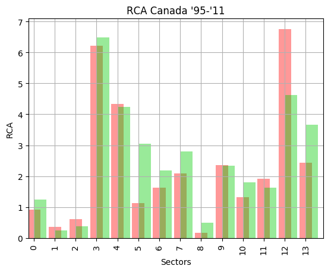

```python
#Histogram of the Revealed Comparative Advantage of Canada

rcacan["1995CAN"].plot(kind = "bar", width = 0.6, color = '#FF3333', alpha=0.5, align='center')
rcacan["2011CAN"].plot(kind = "bar", width = 0.6, color = '#00CC00', alpha=0.4, align='edge')

plt.title("RCA Canada '95-'11")
plt.grid(True)
plt.xlabel('Sectors')
plt.ylabel('RCA')
plt.show()
```

```python
import matplotlib.pyplot as plt; plt.rcdefaults()
import matplotlib.pyplot as plt


rcausa = pd.read_excel(r'C:\Users\Jesse\Downloads\PythonFinal\RCA.xlsx',"RCA_US")
FORMAT = ['Sector', '1995USA', '2011USA']
rcausa_selected = rcausa[FORMAT]
rcausa
```

|  | Sector | 1995USA | 2011USA |
| --- | --- | --- | --- |
| 0 | Food, Beverages and Tobacco | 0.822941 | 0.903910 |
| 1 | Textiles and Textile Products | 1.015098 | 0.644908 |
| 2 | Leather, Leather and Footwear | 0.428503 | 0.016367 |
| 3 | Wood and Products of Wood and Cork | 0.841603 | 0.500987 |
| 4 | Pulp, Paper, Paper , Printing and Publishing | 1.730138 | 1.684969 |
| 5 | Coke, Refined Petroleum and Nuclear Fuel | 0.851702 | 1.858886 |
| 6 | Chemicals and Chemical Products | 2.269695 | 2.827811 |
| 7 | Rubber and Plastics | 1.121627 | 1.228243 |
| 8 | Other Non-Metallic Mineral | 0.154251 | 0.501776 |
| 9 | Basic Metals and Fabricated Metal | 0.865600 | 0.912618 |
| 10 | Machinery, Nec | 3.086419 | 3.024614 |
| 11 | Electrical and Optical Equipment | 4.529056 | 3.311876 |
| 12 | Transport Equipment | 3.303478 | 3.443597 |
| 13 | Manufacturing, Nec; Recycling | 1.909393 | 3.570901 |

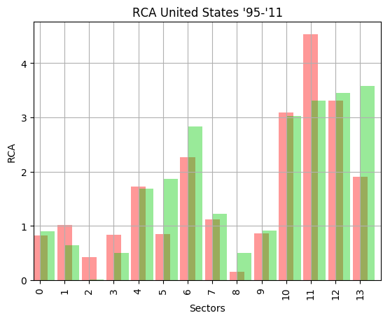

```python
#Histogram of Revealed Comparative Advantage of the USA

rcaus = pd.read_excel(r'C:\Users\Jesse\Downloads\PythonFinal\RCA.xlsx', "RCA_US")
FORMAT = ['Sector','1995USA','2011USA']
rcaus_selected = rcaus[FORMAT]
rcaus

rcaus["1995USA"].plot(kind = "bar", width = 0.6, color = '#FF3333', alpha=0.5, align='center')
rcaus["2011USA"].plot(kind = "bar", width = 0.6, color = '#00CC00', alpha=0.4, align='edge')

plt.title("RCA United States '95-'11")
plt.grid(True)
plt.xlabel('Sectors')
plt.ylabel('RCA')
plt.show()
```

The sectors that lose their RCA relatively to 1995 are 'Textiles and Textile Products', 'Leather, Leather and Footwear' and especially 'Wood and Products of Wood and Cork'. The latter is now traded relatively more traded by Canada with the US, and that is possibly the reason for such a big loss in that sector.

```python
rcamex = pd.read_excel(r'C:\Users\Jesse\Downloads\PythonFinal\RCA.xlsx', "RCA_MEX")
FORMAT = ['Sector','1995MEX','2011MEX']
rcamex_selected = rcamex[FORMAT]
rcamex
```

|  | Sector | 1995MEX | 2011MEX |
| --- | --- | --- | --- |
| 0 | Food, Beverages and Tobacco | 0.580384 | 0.905391 |
| 1 | Textiles and Textile Products | 2.425371 | 1.716744 |
| 2 | Leather, Leather and Footwear | 2.337024 | 1.904892 |
| 3 | Wood and Products of Wood and Cork | 0.436887 | 0.027923 |
| 4 | Pulp, Paper, Paper , Printing and Publishing | 0.252881 | 0.221937 |
| 5 | Coke, Refined Petroleum and Nuclear Fuel | 0.194637 | 0.559461 |
| 6 | Chemicals and Chemical Products | 1.302096 | 1.232839 |
| 7 | Rubber and Plastics | 1.488808 | 1.802052 |
| 8 | Other Non-Metallic Mineral | 1.036661 | 0.804388 |
| 9 | Basic Metals and Fabricated Metal | 1.607223 | 2.138176 |
| 10 | Machinery, Nec | 0.694764 | 1.525615 |
| 11 | Electrical and Optical Equipment | 5.735456 | 7.565977 |
| 12 | Transport Equipment | 1.128785 | 6.300395 |
| 13 | Manufacturing, Nec; Recycling | 0.060095 | 3.832545 |

[figure not shown]

```python
#Histogram of Revealed Comparative Advantage of the Mexico

rcamex = pd.read_excel(r'C:\Users\Jesse\Downloads\PythonFinal\RCA.xlsx', "RCA_MEX")
FORMAT = ['Sector','1995MEX','2011MEX']
rcamex_selected = rcaus[FORMAT]
rcamex

rcaus["1995MEX"].plot(kind = "bar", width = 0.6, color = '#FF3333', alpha=0.5, align='center')
rcaus["2011MEX"].plot(kind = "bar", width = 0.6, color = '#00CC00', alpha=0.4, align='edge')

plt.title("RCA Mexico '95-'11")
plt.grid(True)
plt.xlabel('Sectors')
plt.ylabel('RCA')
plt.show()
```

Based on the RCA analysis, we can draw the same conclusions as based on the analysis of the input-outputtables. Namely, that there is indeed a very strong regional North-American value chain, centralised around the US. The trade among the three countries was already large before NAFTA, so it did not play an enourmous role. However, after the NAFTA agreement, the three countries became more specialised in their comparative advantages. These are in the same sectors for the US and Canada and are situated in different sectors for Mexico. Important to keep in mind, the US keeps trading more with Canada and Mexico, than the latter two countries with each other.

## 5 Conclusion

"Nafta talks are at a 'much better' point, says Mexico" - that is a BBC News headline on January 29, 2018. The latest talks between three countries aim to renegotiate the Nafta agreement, due to the threats of President Donald Trump to withdraw from the agreement. See as an example for that a very short fragment from the Fox News on January 15, 2018. Because of these renewed talks we aimed to take a closer look at this agreement from an economical point of view.

In this project we aimed to analyze the existence of the (regional) North-American value chain and its evolution through time. Furthermore, we investigated whether or not the North American Free Trade Agreement (NAFTA) has played an important role. We looked at the trade flows in intermediate manufacturing inputs between the three countries in 1995 and 2011. The conclusion was that the three partner countries have all known a big increase in trade with each other, in absolute terms and indeed the GVC in North-America is more of a regional value chain.

Secondly, to answer the research question of what role did Nafta played the realization of this regional value chain, we looked at the evolution of the comparative advantage (RCA). We concluded that there is indeed a very strong regional North-American value chain, centralised around the US. The trade among the three countries was already large before NAFTA, so it did not play an enourmous role. However, after the NAFTA agreement, the three countries became more specialised in their comparative advantages. These are in the same sectors for the US and Canada and are situated in different sectors for Mexico. Which is a possible reason why Mexico profits relatively more from the trade agreement than the high-income countries US and Canada. Important to keep in mind, the US keeps trading more with Canada and Mexico, than the latter two countries with each other.

Lastly, it is interesting to note, we did not take any socio-economic accounts into our analysis and did not try to explain the evolution of the trade flows of the inputs. It is important that in other future models this happens and we can look at the labor mobility between different sectors within each country to analyze the effects of NAFTA. Another future research option would be to compute a sensitivity analysis of the trade flows between US and Brazil, for instance. Brazil is a country with comparable wages and educational degrees to Mexico and is not part of the NAFTA agreement. Further, after a historically tense relationship between US and Brazil, the countries started trading with each other after 2009, when a bilateral trade agreement between the two countries came into place.

```python
from IPython.display import YouTubeVideo

YouTubeVideo('RJrxjXq1cDI')
```

[video not shown]

Click here to go back to the top